# Statistical analyses and plotting for *Xylaria necrophora* secondary metabolites experiments

Teddy Garcia-Aroca

October 29, 2021

# Install packages needed.

## We first create a vector of all the packages needed

```r
packages <- c("agricolae", "dplyr", "plyr", "ggplot2", "readr", "ggpubr", "car", "rcompanion", "tidyverse", "ggsignif", "reshape")
```

## Install packages not yet installed

```r
installed_packages <- packages %in% rownames(installed.packages())
if (any(installed_packages == FALSE)) {
  install.packages(packages[!installed_packages])
}
```

## Load all packages

```r
invisible(lapply(packages, library, character.only = TRUE))
```

# Set the working directory to the directory where the output files will be saved.

In this case, we assume you have cloned/donwloaded this repository to your “Documents” folder.

Change directory on mac/linux:

setwd(“/Users/YOURUSERNAME/Documents/X.necrophora.secondaryMetabolites/output”)

Change directory on Windows (Windows 10 in this example):

setwd(“C:/Users/YOURUSERNAME/Documents/X.necrophora.secondaryMetabolites/output”)

## For this demosntration, we did not export the files in PDF to the output directory. If you wish to do so, do the following:

### Step 1: Call the pdf command to start the plot

```
pdf(file = "/Users/YOURUSERNAME/Documents/X.necrophora.secondaryMetabolites/output/ Figure1.pdf",   # The directory you want to save the file in

width = 7, # The width of the plot in inches

height = 5) # The height of the plot in inches
```

### Step 2: Add the code provided below for your desired plot.

### Step 3: Run dev.off() to create the file!

```
dev.off()
```

## For this example, we set the working directory to the following:

```r
setwd("/Users/tedggarcia/Documents/X.necrophora.secondaryMetabolites/output/")
```

# Loading digital Chlorophyll content datasets (only one repetition of each experiment for illustration purposes). All datasets can be found in the folder named “raw_data”

ES2 = First experiment for 14 Days of exporuse (DOE)

#ES4 = Repetetion for 14 DOE

ES5 = First experiment for 7 DOE

#ES8 = Repetition for 7 DOE

#ES13A = Experiment testing potentially resistant cultivars (7DOE)

ES13B = Repetition of ES13A

ES14A = Experiment testing effects among plant species (7DOE)

#ES14B = Repetition of ES14A

```r
ES2 <- read.csv("../raw_data/ES2.ChlorophyllContent.14DOE.Exp1.csv", header = T)
ES5 <- read.csv("../raw_data/ES5.ChlorophyllContent.7DOE.Exp1.csv", header = T)
ES13B <- read.csv("../raw_data/ES13B.ChlorophyllContent.7DOE.Exp2.Cultivars.csv", header = T)
ES14A <- read.csv("../raw_data/ES14A.ChlorophyllContent.7DOE.Exp1.PlantSpecies.csv", header = T)
```

## Run Shapiro-Wilk Tests to check for normality

```r
shapiro.test(ES2$chl)
```

```
##
##  Shapiro-Wilk normality test
##
## data:  ES2$chl
## W = 0.74674, p-value < 2.2e-16
```

```r
shapiro.test(ES5$chl)
```

```
##
##  Shapiro-Wilk normality test
##
## data:  ES5$chl
## W = 0.95514, p-value = 5.341e-10
```

```r
shapiro.test(ES13B$chl)
```

```
##
##  Shapiro-Wilk normality test
##
## data:  ES13B$chl
## W = 0.95496, p-value = 2.7e-07
```

```r
shapiro.test(ES14A$chl)
```

```
##
##  Shapiro-Wilk normality test
##
## data:  ES14A$chl
## W = 0.95203, p-value = 1.513e-06
```

## Check the distribution of the data and assess if normalization is needed.

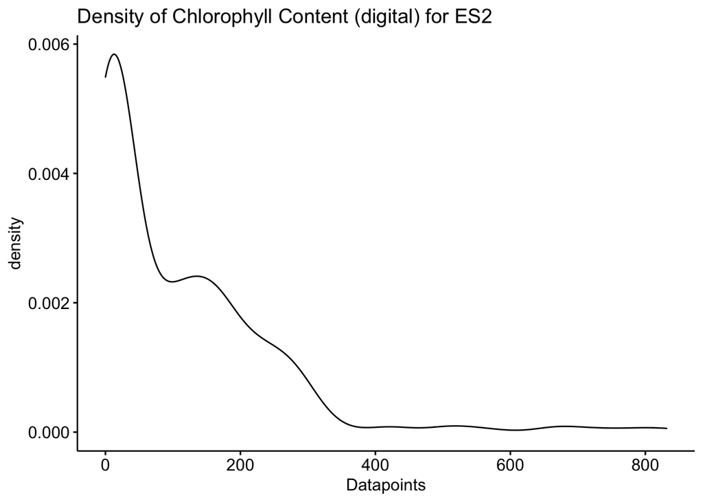

```r
ggdensity(ES2$chl, main = "Density of Chlorophyll Content (digital) for ES2", xlab = "Datapoints")
```

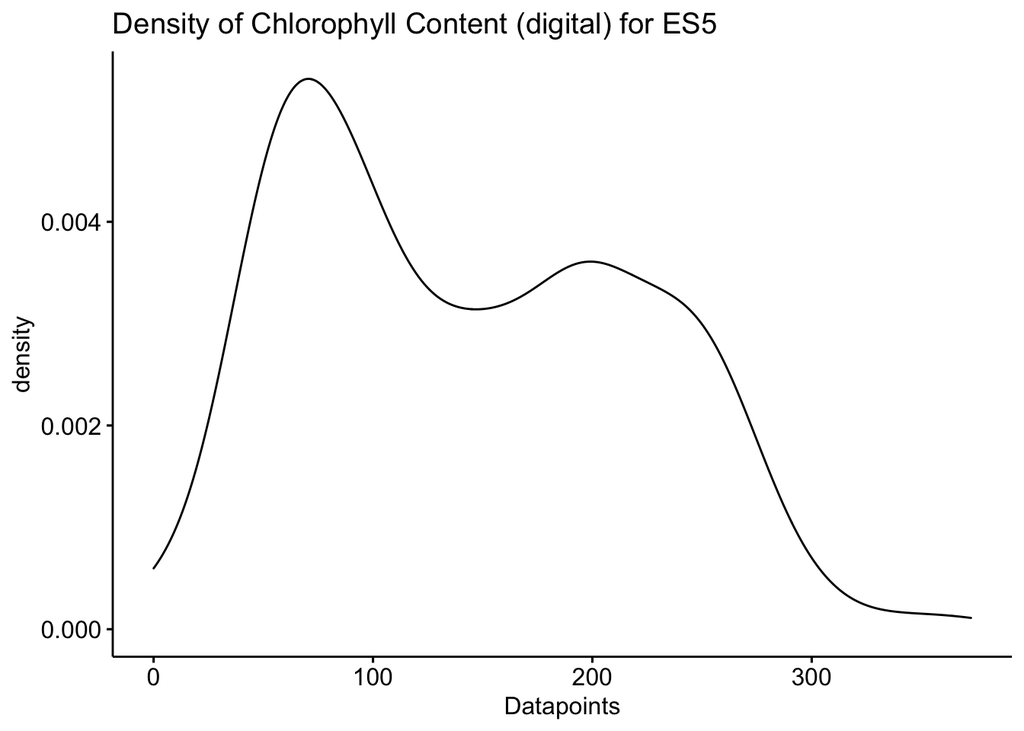

```r
ggdensity(ES5$chl, main = "Density of Chlorophyll Content (digital) for ES5", xlab = "Datapoints")
```

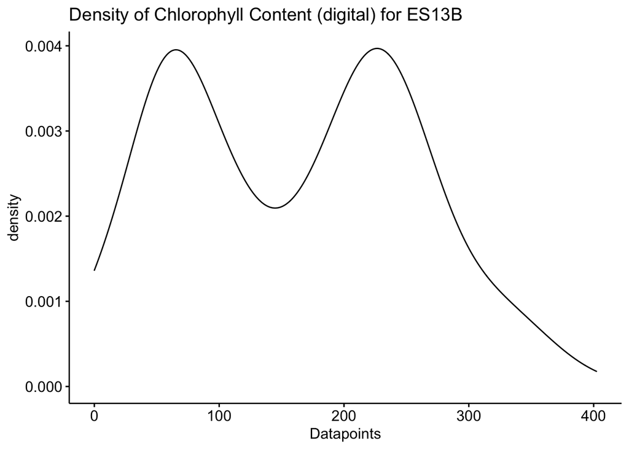

```r
ggdensity(ES13B$chl, main = "Density of Chlorophyll Content (digital) for ES13B", xlab = "Datapoints")
```

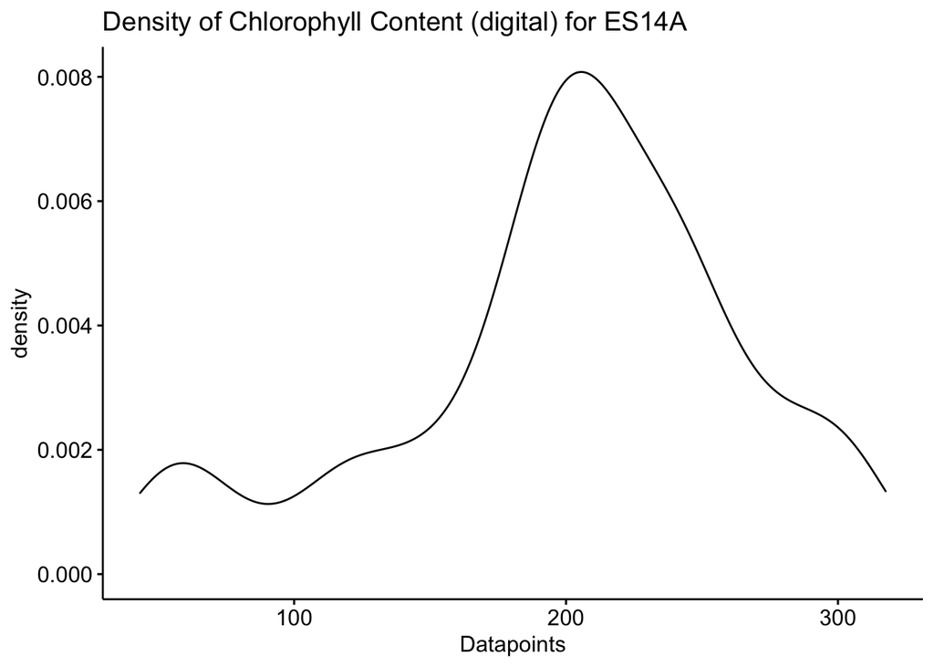

```r
ggdensity(ES14A$chl, main = "Density of Chlorophyll Content (digital) for ES14A", xlab = "Datapoints")
```

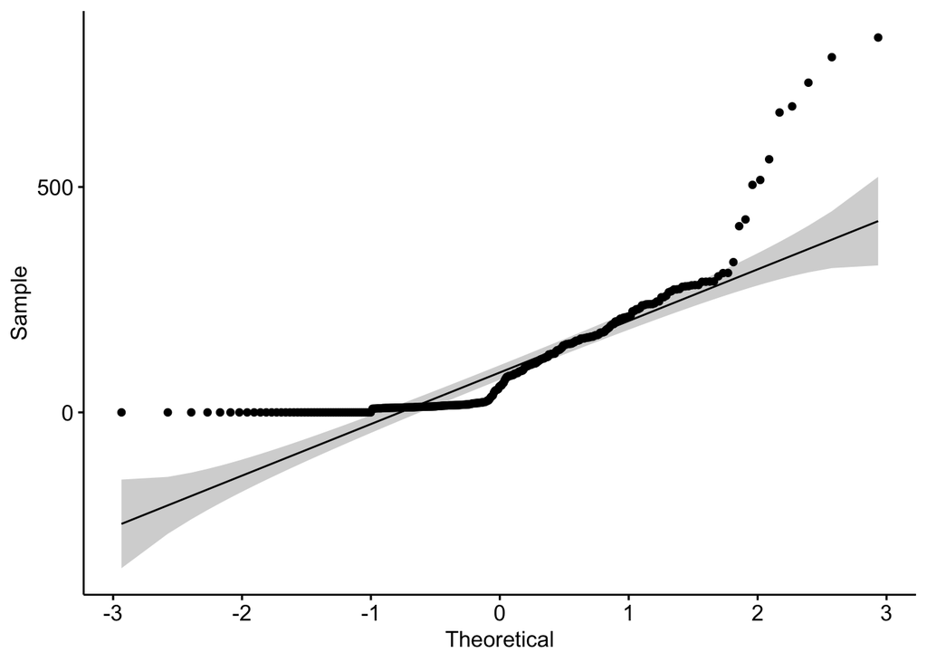

```r
ggqqplot(ES2$chl)
```

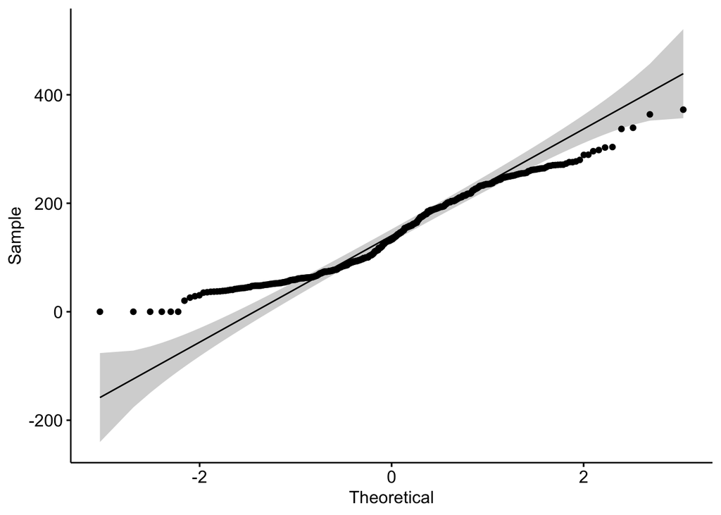

```r
ggqqplot(ES5$chl)
```

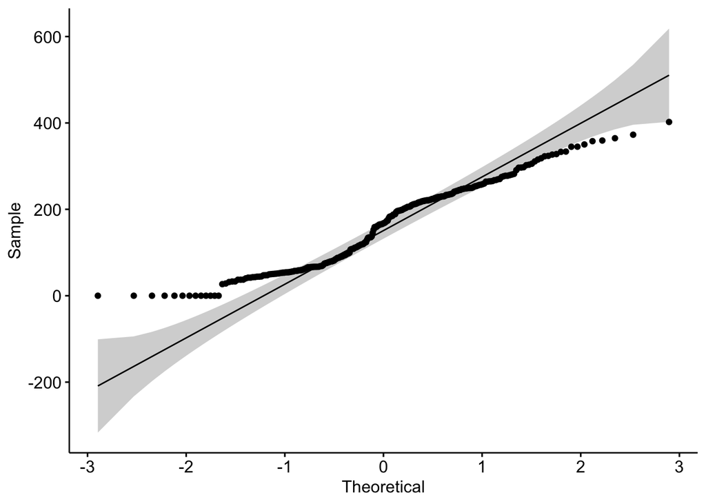

```r
ggqqplot(ES13B$chl)
```

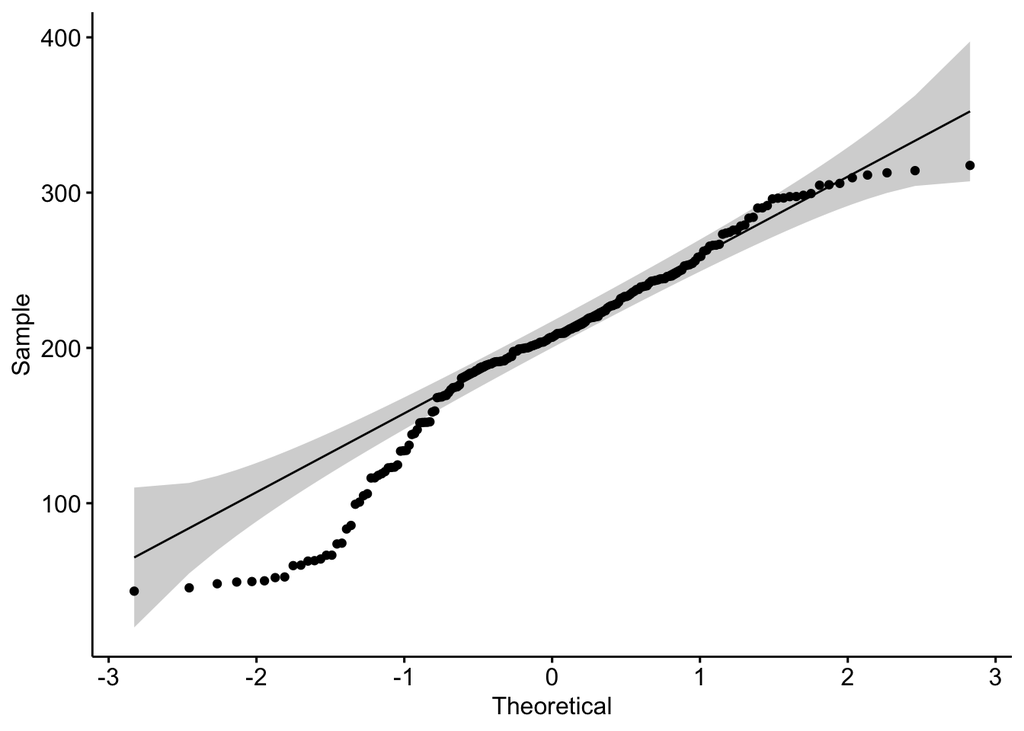

```r
ggqqplot(ES14A$chl)
```

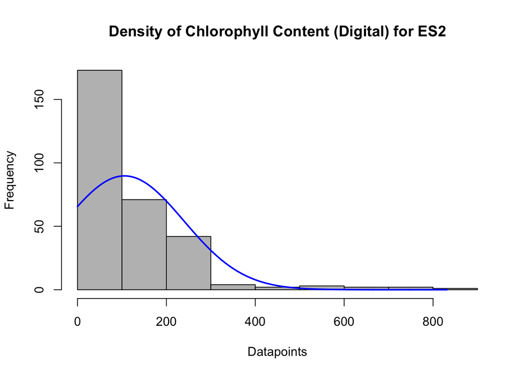

```r
plotNormalHistogram(ES2$chl, main = "Density of Chlorophyll Content (Digital) for ES2", xlab = "Datapoints")
```

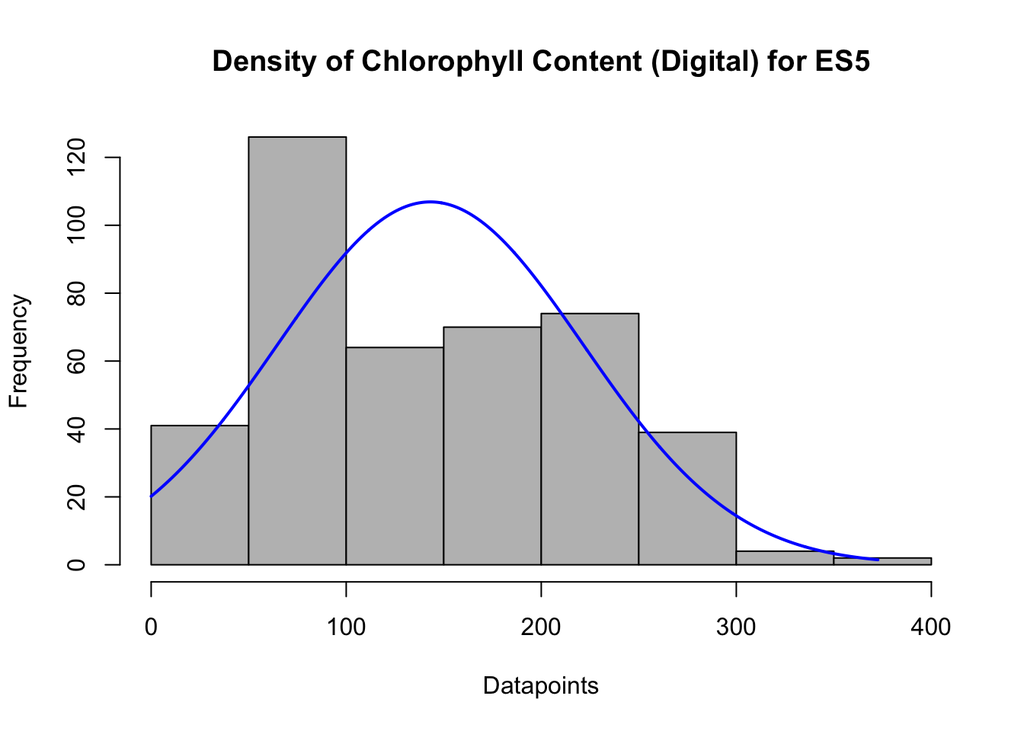

```r
plotNormalHistogram(ES5$chl, main = "Density of Chlorophyll Content (Digital) for ES5", xlab = "Datapoints")
```

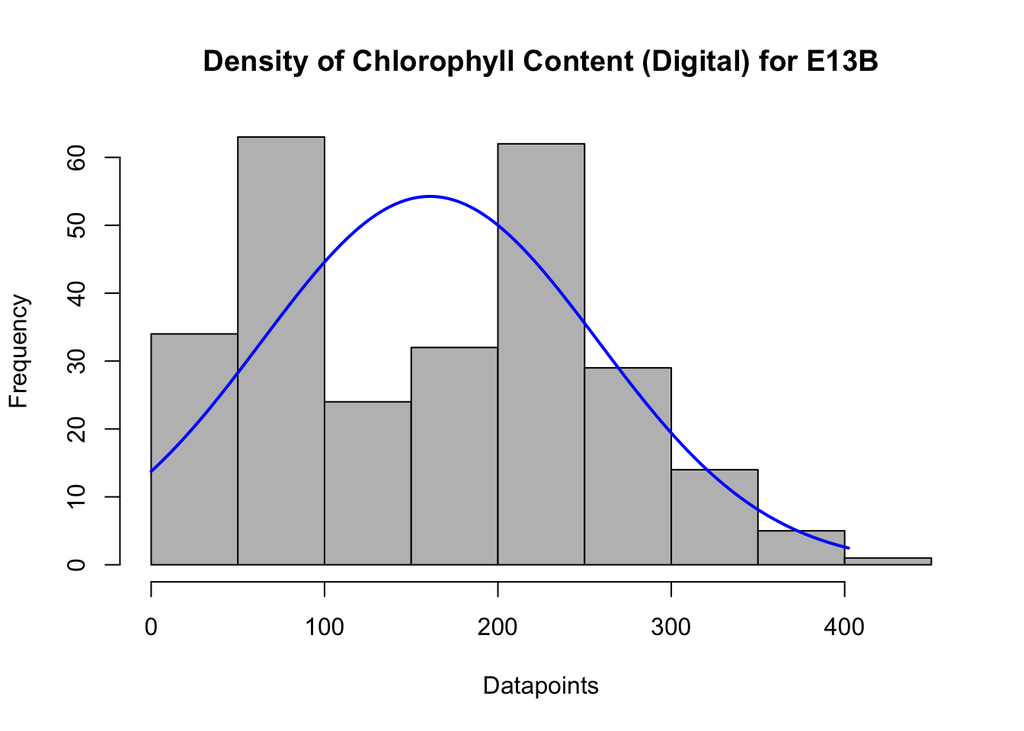

```r
plotNormalHistogram(ES13B$chl, main = "Density of Chlorophyll Content (Digital) for E13B", xlab = "Datapoints")
```

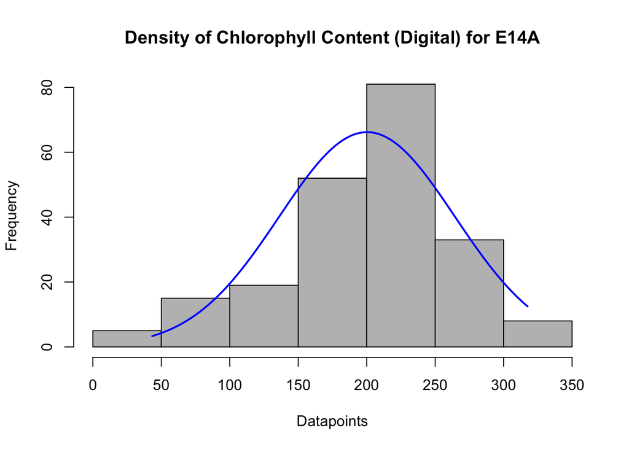

```r
plotNormalHistogram(ES14A$chl, main = "Density of Chlorophyll Content (Digital) for E14A", xlab = "Datapoints")
```

## Use the Tukey’s tranformation method to normalize the distribution and append to datasets

```r
ES2_chl.tuk = transformTukey(ES2$chl, plotit=FALSE)
```

```
##
##     lambda      W Shapiro.p.value
## 416  0.375 0.9449       3.664e-09
##
## if (lambda >  0){TRANS = x ^ lambda}
## if (lambda == 0){TRANS = log(x)}
## if (lambda <  0){TRANS = -1 * x ^ lambda}
```

```r
ES5_chl.tuk = transformTukey(ES5$chl, plotit=FALSE)
```

```
##
##     lambda      W Shapiro.p.value
## 427   0.65 0.9695       1.098e-07
##
## if (lambda >  0){TRANS = x ^ lambda}
## if (lambda == 0){TRANS = log(x)}
## if (lambda <  0){TRANS = -1 * x ^ lambda}
```

```r
ES13B_chl.tuk = transformTukey(ES13B$chl, plotit=FALSE)
```

```
##
##     lambda      W Shapiro.p.value
## 432  0.775 0.9604       1.226e-06
##
## if (lambda >  0){TRANS = x ^ lambda}
## if (lambda == 0){TRANS = log(x)}
## if (lambda <  0){TRANS = -1 * x ^ lambda}
```

```r
ES14A_chl.tuk = transformTukey(ES14A$chl, plotit=FALSE)
```

```
##
##     lambda     W Shapiro.p.value
## 470  1.725 0.979         0.00282
##
## if (lambda >  0){TRANS = x ^ lambda}
## if (lambda == 0){TRANS = log(x)}
## if (lambda <  0){TRANS = -1 * x ^ lambda}
```

## Append the transformed values to original datasets

```r
ES2.mod <- cbind(ES2, ES2_chl.tuk)
ES5.mod <- cbind(ES5, ES5_chl.tuk)
ES13B.mod <- cbind(ES13B, ES13B_chl.tuk)
ES14A.mod <- cbind(ES14A, ES14A_chl.tuk)
```

# Statistical analyses

Run ANOVA and Tukey’s honest significance differences for raw chlorophyll content.

## ES2 dataset (untransformed data)

As desribed above, this experiment was ran using cell-free culture filtrates (CFCFs) from three local strains of *Xylaria necrophora* (DMCC2126, DMCC2127, and DMCC2165) and one *Colletotrichum siamense* (DMCC2966) for 14 days (ES2)

```r
###############ES2 analysis################################
ES2.chl.anova <- lm (ES2$chl ~ ES2$Treatment + ES2$Dilution + ES2$Condition + ES2$isoRep + ES2$techRep + ES2$sampleNumber)
ES2.chl.anova
```

```
##
## Call:
## lm(formula = ES2$chl ~ ES2$Treatment + ES2$Dilution + ES2$Condition +
##     ES2$isoRep + ES2$techRep + ES2$sampleNumber)
##
## Coefficients:
##             (Intercept)    ES2$TreatmentDMCC2126    ES2$TreatmentDMCC2127
##                 236.806                 -140.175                 -173.159
##   ES2$TreatmentDMCC2165    ES2$TreatmentDMCC2966       ES2$Dilution25fold
##                -169.865                  -44.126                 -102.848
## ES2$ConditionStationary    ES2$isoRepisolateRep2         ES2$techRepStem2
##                  -8.823                   23.729                  -24.695
##        ES2$techRepStem3  ES2$sampleNumbersample2  ES2$sampleNumbersample3
##                  16.950                   26.386                   30.435
```

```r
summary(ES2.chl.anova)
```

```
##
## Call:
## lm(formula = ES2$chl ~ ES2$Treatment + ES2$Dilution + ES2$Condition +
##     ES2$isoRep + ES2$techRep + ES2$sampleNumber)
##
## Residuals:
##     Min      1Q  Median      3Q     Max
## -231.24  -49.47    1.55   41.40  536.42
##
## Coefficients:
##                         Estimate Std. Error t value Pr(>|t|)
## (Intercept)              236.806     20.365  11.628  < 2e-16 ***
## ES2$TreatmentDMCC2126   -140.175     18.956  -7.395 1.70e-12 ***
## ES2$TreatmentDMCC2127   -173.159     19.204  -9.017  < 2e-16 ***
## ES2$TreatmentDMCC2165   -169.865     18.952  -8.963  < 2e-16 ***
## ES2$TreatmentDMCC2966    -44.126     18.481  -2.388   0.0176 *
## ES2$Dilution25fold      -102.848     11.998  -8.572 7.35e-16 ***
## ES2$ConditionStationary   -8.823     11.944  -0.739   0.4607
## ES2$isoRepisolateRep2     23.729     11.964   1.983   0.0483 *
## ES2$techRepStem2         -24.695     15.316  -1.612   0.1080
## ES2$techRepStem3          16.950     14.020   1.209   0.2277
## ES2$sampleNumbersample2   26.386     14.436   1.828   0.0687 .
## ES2$sampleNumbersample3   30.435     14.489   2.101   0.0366 *
## ---
## Signif. codes:  0 '***' 0.001 '**' 0.01 '*' 0.05 '.' 0.1 ' ' 1
##
## Residual standard error: 100.5 on 276 degrees of freedom
##   (72 observations deleted due to missingness)
## Multiple R-squared:  0.4591, Adjusted R-squared:  0.4375
## F-statistic:  21.3 on 11 and 276 DF,  p-value: < 2.2e-16
```

```r
anova(ES2.chl.anova)
```

```
## Analysis of Variance Table
##
## Response: ES2$chl
##                   Df  Sum Sq Mean Sq F value    Pr(>F)
## ES2$Treatment      4 1458908  364727 36.1018 < 2.2e-16 ***
## ES2$Dilution       1  732380  732380 72.4932 1.094e-15 ***
## ES2$Condition      1    3246    3246  0.3213   0.57128
## ES2$isoRep         1   38119   38119  3.7732   0.05310 .
## ES2$techRep        2   80731   40366  3.9955   0.01947 *
## ES2$sampleNumber   2   53280   26640  2.6369   0.07338 .
## Residuals        276 2788355   10103
## ---
## Signif. codes:  0 '***' 0.001 '**' 0.01 '*' 0.05 '.' 0.1 ' ' 1
```

```r
#Tukey's HSD for Variable chl (tukey trans) by Treament
ES2.chl.treatment.HSD.test <- HSD.test(ES2.chl.anova, 'ES2$Treatment', group = T)
ES2.chl.treatment.HSD.test
```

```
## $statistics
##    MSerror  Df     Mean       CV
##   10102.73 276 105.3393 95.41771
##
## $parameters
##    test        name.t ntr StudentizedRange alpha
##   Tukey ES2$Treatment   5         3.883285  0.05
##
## $means
##            ES2$chl       std  r Min     Max       Q25     Q50       Q75
## control  206.91423 217.07353 57   0 831.472  26.54900 138.046 272.67000
## DMCC2126  73.25279  74.61783 57   0 281.899  11.31300  29.554 129.60000
## DMCC2127  37.91085  49.89550 54   0 167.994   8.52575  15.327  49.05425
## DMCC2165  30.48823  45.19861 57   0 187.945   8.36200  14.000  20.43000
## DMCC2966 167.98710  89.73008 63   0 309.266 119.20850 177.714 233.30650
##
## $comparison
## NULL
##
## $groups
##            ES2$chl groups
## control  206.91423      a
## DMCC2966 167.98710      a
## DMCC2126  73.25279      b
## DMCC2127  37.91085      b
## DMCC2165  30.48823      b
##
## attr(,"class")
## [1] "group"
```

```r
#Tukey's HSD for Variable chl (tukey trans) by Dilution
ES2.chl.dilution.HSD.test <- HSD.test(ES2.chl.anova, 'ES2$Dilution', group = T)
ES2.chl.dilution.HSD.test
```

```
## $statistics
##    MSerror  Df     Mean       CV
##   10102.73 276 105.3393 95.41771
##
## $parameters
##    test       name.t ntr StudentizedRange alpha
##   Tukey ES2$Dilution   2         2.784016  0.05
##
## $means
##           ES2$chl       std   r Min     Max      Q25      Q50       Q75
## 100fold 157.13270 159.97363 138   0 831.472 36.10000 129.1440 206.71875
## 25fold   57.68939  79.35162 150   0 309.266  9.85425  15.6685  99.75575
##
## $comparison
## NULL
##
## $groups
##           ES2$chl groups
## 100fold 157.13270      a
## 25fold   57.68939      b
##
## attr(,"class")
## [1] "group"
```

```r
#Tukey's HSD for Variable chl (tukey trans) by isoRep
ES2.chl.isoRep.HSD.test <- HSD.test(ES2.chl.anova, 'ES2$isoRep', group = T)
ES2.chl.isoRep.HSD.test
```

```
## $statistics
##    MSerror  Df     Mean       CV
##   10102.73 276 105.3393 95.41771
##
## $parameters
##    test     name.t ntr StudentizedRange alpha
##   Tukey ES2$isoRep   2         2.784016  0.05
##
## $means
##               ES2$chl      std   r Min     Max     Q25    Q50      Q75
## isolateRep1  95.20639 127.0337 147   0 678.735 10.5195 24.386 138.3605
## isolateRep2 115.90342 140.6136 141   0 831.472 14.0000 85.555 171.1230
##
## $comparison
## NULL
##
## $groups
##               ES2$chl groups
## isolateRep2 115.90342      a
## isolateRep1  95.20639      a
##
## attr(,"class")
## [1] "group"
```

```r
#Complete ANOVA for ES2 by treatment by dilution
ES2.comp.HSD.group <- HSD.test(ES2.chl.anova, c("ES2$Treatment", "ES2$Dilution"), group=TRUE,console=TRUE)
```

```
##
## Study: ES2.chl.anova ~ c("ES2$Treatment", "ES2$Dilution")
##
## HSD Test for ES2$chl
##
## Mean Square Error:  10102.73
##
## ES2$Treatment:ES2$Dilution,  means
##
##                     ES2.chl        std  r    Min     Max
## control:100fold  383.864000 223.675014 24 97.748 831.472
## control:25fold    78.223485  77.070835 33  0.000 268.776
## DMCC2126:100fold 127.480933  64.977439 30 10.433 281.899
## DMCC2126:25fold   12.999296  10.944223 27  0.000  51.676
## DMCC2127:100fold  58.980593  59.597226 27  0.000 167.994
## DMCC2127:25fold   16.841111  24.515869 27  0.000 112.319
## DMCC2165:100fold  58.801375  58.889805 24  0.000 187.945
## DMCC2165:25fold    9.896848   6.632284 33  0.000  19.414
## DMCC2966:100fold 171.013333  97.165275 33  0.000 301.867
## DMCC2966:25fold  164.658233  82.303611 30  0.000 309.266
##
## Alpha: 0.05 ; DF Error: 276
## Critical Value of Studentized Range: 4.511094
##
## Groups according to probability of means differences and alpha level( 0.05 )
##
## Treatments with the same letter are not significantly different.
##
##                     ES2$chl groups
## control:100fold  383.864000      a
## DMCC2966:100fold 171.013333      b
## DMCC2966:25fold  164.658233      b
## DMCC2126:100fold 127.480933     bc
## control:25fold    78.223485     cd
## DMCC2127:100fold  58.980593     cd
## DMCC2165:100fold  58.801375     cd
## DMCC2127:25fold   16.841111      d
## DMCC2126:25fold   12.999296      d
## DMCC2165:25fold    9.896848      d
```

```r
ES2.comp.HSD.group
```

```
## $statistics
##    MSerror  Df     Mean       CV
##   10102.73 276 105.3393 95.41771
##
## $parameters
##    test                     name.t ntr StudentizedRange alpha
##   Tukey ES2$Treatment:ES2$Dilution  10         4.511094  0.05
##
## $means
##                     ES2$chl        std  r    Min     Max       Q25      Q50
## control:100fold  383.864000 223.675014 24 97.748 831.472 244.69000 280.5385
## control:25fold    78.223485  77.070835 33  0.000 268.776  15.68300  59.4900
## DMCC2126:100fold 127.480933  64.977439 30 10.433 281.899  81.64425 129.1440
## DMCC2126:25fold   12.999296  10.944223 27  0.000  51.676   9.86550  11.3130
## DMCC2127:100fold  58.980593  59.597226 27  0.000 167.994  12.11000  35.6240
## DMCC2127:25fold   16.841111  24.515869 27  0.000 112.319   0.00000  11.9040
## DMCC2165:100fold  58.801375  58.889805 24  0.000 187.945  14.21225  25.3885
## DMCC2165:25fold    9.896848   6.632284 33  0.000  19.414   0.00000  12.2830
## DMCC2966:100fold 171.013333  97.165275 33  0.000 301.867 118.40500 176.8540
## DMCC2966:25fold  164.658233  82.303611 30  0.000 309.266 120.78250 181.5795
##                       Q75
## control:100fold  527.0058
## control:25fold   129.7670
## DMCC2126:100fold 159.8775
## DMCC2126:25fold   16.5335
## DMCC2127:100fold  90.5650
## DMCC2127:25fold   15.6860
## DMCC2165:100fold 105.9032
## DMCC2165:25fold   14.7740
## DMCC2966:100fold 241.9460
## DMCC2966:25fold  222.5877
##
## $comparison
## NULL
##
## $groups
##                     ES2$chl groups
## control:100fold  383.864000      a
## DMCC2966:100fold 171.013333      b
## DMCC2966:25fold  164.658233      b
## DMCC2126:100fold 127.480933     bc
## control:25fold    78.223485     cd
## DMCC2127:100fold  58.980593     cd
## DMCC2165:100fold  58.801375     cd
## DMCC2127:25fold   16.841111      d
## DMCC2126:25fold   12.999296      d
## DMCC2165:25fold    9.896848      d
##
## attr(,"class")
## [1] "group"
```

```r
#Complete ANOVA for ES2 by treatment by condition, by dilution
ES2.comp.HSD.group <- HSD.test(ES2.chl.anova, c("ES2$Treatment", "ES2$Condition", "ES2$Dilution"), group=TRUE,console=TRUE)
```

```
##
## Study: ES2.chl.anova ~ c("ES2$Treatment", "ES2$Condition", "ES2$Dilution")
##
## HSD Test for ES2$chl
##
## Mean Square Error:  10102.73
##
## ES2$Treatment:ES2$Condition:ES2$Dilution,  means
##
##                                ES2.chl        std  r     Min     Max
## control:Shaking:100fold     365.312600 219.329463 15 117.742 787.887
## control:Shaking:25fold       83.216056  81.789480 18   0.000 268.776
## control:Stationary:100fold  414.783000 240.691662  9  97.748 831.472
## control:Stationary:25fold    72.232400  73.372023 15   0.000 237.395
## DMCC2126:Shaking:100fold    107.106250  88.648073 12  10.433 281.899
## DMCC2126:Shaking:25fold      11.166278   8.588222 18   0.000  29.554
## DMCC2126:Stationary:100fold 141.064056  40.361686 18  58.992 207.739
## DMCC2126:Stationary:25fold   16.665333  14.486460  9   0.000  51.676
## DMCC2127:Shaking:100fold     27.384333  29.312311 12   0.000  87.367
## DMCC2127:Shaking:25fold      12.535833   6.846127 12   0.000  23.493
## DMCC2127:Stationary:100fold  84.257600  66.188284 15   0.000 167.994
## DMCC2127:Stationary:25fold   20.285333  32.415599 15   0.000 112.319
## DMCC2165:Shaking:100fold     37.540750  46.913463 12   0.000 150.248
## DMCC2165:Shaking:25fold      11.067600   6.311390 15   0.000  19.414
## DMCC2165:Stationary:100fold  80.062000  63.751126 12   0.000 187.945
## DMCC2165:Stationary:25fold    8.921222   6.912163 18   0.000  17.639
## DMCC2966:Shaking:100fold    223.958000  61.555261 18 128.523 301.867
## DMCC2966:Shaking:25fold     203.815933  41.016531 15 123.094 282.574
## DMCC2966:Stationary:100fold 107.479733  95.130285 15   0.000 289.798
## DMCC2966:Stationary:25fold  125.500533  95.202754 15   0.000 309.266
##
## Alpha: 0.05 ; DF Error: 276
## Critical Value of Studentized Range: 5.061243
##
## Groups according to probability of means differences and alpha level( 0.05 )
##
## Treatments with the same letter are not significantly different.
##
##                                ES2$chl groups
## control:Stationary:100fold  414.783000      a
## control:Shaking:100fold     365.312600      a
## DMCC2966:Shaking:100fold    223.958000      b
## DMCC2966:Shaking:25fold     203.815933     bc
## DMCC2126:Stationary:100fold 141.064056    bcd
## DMCC2966:Stationary:25fold  125.500533   bcde
## DMCC2966:Stationary:100fold 107.479733   bcde
## DMCC2126:Shaking:100fold    107.106250   bcde
## DMCC2127:Stationary:100fold  84.257600    cde
## control:Shaking:25fold       83.216056    cde
## DMCC2165:Stationary:100fold  80.062000    cde
## control:Stationary:25fold    72.232400     de
## DMCC2165:Shaking:100fold     37.540750     de
## DMCC2127:Shaking:100fold     27.384333     de
## DMCC2127:Stationary:25fold   20.285333     de
## DMCC2126:Stationary:25fold   16.665333     de
## DMCC2127:Shaking:25fold      12.535833     de
## DMCC2126:Shaking:25fold      11.166278      e
## DMCC2165:Shaking:25fold      11.067600      e
## DMCC2165:Stationary:25fold    8.921222      e
```

```r
ES2.comp.HSD.group
```

```
## $statistics
##    MSerror  Df     Mean       CV
##   10102.73 276 105.3393 95.41771
##
## $parameters
##    test                                   name.t ntr StudentizedRange alpha
##   Tukey ES2$Treatment:ES2$Condition:ES2$Dilution  20         5.061243  0.05
##
## $means
##                                ES2$chl        std  r     Min     Max       Q25
## control:Shaking:100fold     365.312600 219.329463 15 117.742 787.887 234.01100
## control:Shaking:25fold       83.216056  81.789480 18   0.000 268.776  11.50550
## control:Stationary:100fold  414.783000 240.691662  9  97.748 831.472 272.67000
## control:Stationary:25fold    72.232400  73.372023 15   0.000 237.395  19.04600
## DMCC2126:Shaking:100fold    107.106250  88.648073 12  10.433 281.899  52.75425
## DMCC2126:Shaking:25fold      11.166278   8.588222 18   0.000  29.554   2.47200
## DMCC2126:Stationary:100fold 141.064056  40.361686 18  58.992 207.739 124.20750
## DMCC2126:Stationary:25fold   16.665333  14.486460  9   0.000  51.676  10.37600
## DMCC2127:Shaking:100fold     27.384333  29.312311 12   0.000  87.367   8.01525
## DMCC2127:Shaking:25fold      12.535833   6.846127 12   0.000  23.493  11.11275
## DMCC2127:Stationary:100fold  84.257600  66.188284 15   0.000 167.994  18.08300
## DMCC2127:Stationary:25fold   20.285333  32.415599 15   0.000 112.319   0.00000
## DMCC2165:Shaking:100fold     37.540750  46.913463 12   0.000 150.248   0.00000
## DMCC2165:Shaking:25fold      11.067600   6.311390 15   0.000  19.414   9.55700
## DMCC2165:Stationary:100fold  80.062000  63.751126 12   0.000 187.945  19.12150
## DMCC2165:Stationary:25fold    8.921222   6.912163 18   0.000  17.639   0.00000
## DMCC2966:Shaking:100fold    223.958000  61.555261 18 128.523 301.867 169.69900
## DMCC2966:Shaking:25fold     203.815933  41.016531 15 123.094 282.574 172.80800
## DMCC2966:Stationary:100fold 107.479733  95.130285 15   0.000 289.798   0.00000
## DMCC2966:Stationary:25fold  125.500533  95.202754 15   0.000 309.266  48.06800
##                                  Q50       Q75
## control:Shaking:100fold     273.5930 510.07500
## control:Shaking:25fold       74.7350 117.59850
## control:Stationary:100fold  413.0270 561.43300
## control:Stationary:25fold    26.5490 133.90650
## DMCC2126:Shaking:100fold     86.9630 129.27900
## DMCC2126:Shaking:25fold      11.0480  16.28075
## DMCC2126:Stationary:100fold 152.6480 165.71925
## DMCC2126:Stationary:25fold   12.4910  17.61900
## DMCC2127:Shaking:100fold     16.4120  36.10000
```

[output cut: 25 more lines]

```
## DMCC2127:Stationary:100fold  84.257600    cde
## control:Shaking:25fold       83.216056    cde
## DMCC2165:Stationary:100fold  80.062000    cde
## control:Stationary:25fold    72.232400     de
## DMCC2165:Shaking:100fold     37.540750     de
## DMCC2127:Shaking:100fold     27.384333     de
## DMCC2127:Stationary:25fold   20.285333     de
## DMCC2126:Stationary:25fold   16.665333     de
## DMCC2127:Shaking:25fold      12.535833     de
## DMCC2126:Shaking:25fold      11.166278      e
## DMCC2165:Shaking:25fold      11.067600      e
## DMCC2165:Stationary:25fold    8.921222      e
##
## attr(,"class")
## [1] "group"
```

## Same analysis using the normalized dataset

```r
###############ES2 analysis (normalized dataset) ################################
ES2.mod.chl.anova <- lm (ES2.mod$ES2_chl.tuk ~ ES2.mod$Treatment + ES2.mod$Dilution + ES2.mod$Condition + ES2.mod$isoRep + ES2.mod$techRep + ES2.mod$sampleNumber)
ES2.mod.chl.anova
```

```
##
## Call:
## lm(formula = ES2.mod$ES2_chl.tuk ~ ES2.mod$Treatment + ES2.mod$Dilution +
##     ES2.mod$Condition + ES2.mod$isoRep + ES2.mod$techRep + ES2.mod$sampleNumber)
##
## Coefficients:
##                 (Intercept)    ES2.mod$TreatmentDMCC2126
##                     7.52662                     -2.19660
##   ES2.mod$TreatmentDMCC2127    ES2.mod$TreatmentDMCC2165
##                    -3.39025                     -3.45003
##   ES2.mod$TreatmentDMCC2966       ES2.mod$Dilution25fold
##                    -0.21011                     -2.34945
## ES2.mod$ConditionStationary    ES2.mod$isoRepisolateRep2
##                    -0.09975                      0.73788
##        ES2.mod$techRepStem2         ES2.mod$techRepStem3
##                    -0.70265                     -0.27113
## ES2.mod$sampleNumbersample2  ES2.mod$sampleNumbersample3
##                    -0.03389                     -0.09430
```

```r
summary(ES2.mod.chl.anova)
```

```
##
## Call:
## lm(formula = ES2.mod$ES2_chl.tuk ~ ES2.mod$Treatment + ES2.mod$Dilution +
##     ES2.mod$Condition + ES2.mod$isoRep + ES2.mod$techRep + ES2.mod$sampleNumber)
##
## Residuals:
##     Min      1Q  Median      3Q     Max
## -7.1829 -1.1889  0.4416  1.2936  4.5838
##
## Coefficients:
##                             Estimate Std. Error t value Pr(>|t|)
## (Intercept)                  7.52662    0.44329  16.979  < 2e-16 ***
## ES2.mod$TreatmentDMCC2126   -2.19660    0.41262  -5.323 2.11e-07 ***
## ES2.mod$TreatmentDMCC2127   -3.39025    0.41803  -8.110 1.67e-14 ***
## ES2.mod$TreatmentDMCC2165   -3.45003    0.41254  -8.363 3.06e-15 ***
## ES2.mod$TreatmentDMCC2966   -0.21011    0.40229  -0.522  0.60190
## ES2.mod$Dilution25fold      -2.34945    0.26117  -8.996  < 2e-16 ***
## ES2.mod$ConditionStationary -0.09975    0.26000  -0.384  0.70152
## ES2.mod$isoRepisolateRep2    0.73788    0.26043   2.833  0.00495 **
## ES2.mod$techRepStem2        -0.70265    0.33340  -2.108  0.03597 *
## ES2.mod$techRepStem3        -0.27113    0.30518  -0.888  0.37510
## ES2.mod$sampleNumbersample2 -0.03389    0.31425  -0.108  0.91420
## ES2.mod$sampleNumbersample3 -0.09430    0.31539  -0.299  0.76518
## ---
## Signif. codes:  0 '***' 0.001 '**' 0.01 '*' 0.05 '.' 0.1 ' ' 1
##
## Residual standard error: 2.188 on 276 degrees of freedom
##   (72 observations deleted due to missingness)
## Multiple R-squared:  0.4559, Adjusted R-squared:  0.4342
## F-statistic: 21.02 on 11 and 276 DF,  p-value: < 2.2e-16
```

```r
anova(ES2.mod.chl.anova)
```

```
## Analysis of Variance Table
##
## Response: ES2.mod$ES2_chl.tuk
##                       Df  Sum Sq Mean Sq F value    Pr(>F)
## ES2.mod$Treatment      4  680.08  170.02 35.5165 < 2.2e-16 ***
## ES2.mod$Dilution       1  367.55  367.55 76.7802 < 2.2e-16 ***
## ES2.mod$Condition      1    0.63    0.63  0.1326  0.716072
## ES2.mod$isoRep         1   36.95   36.95  7.7190  0.005839 **
## ES2.mod$techRep        2   21.22   10.61  2.2166  0.110912
## ES2.mod$sampleNumber   2    0.44    0.22  0.0456  0.955457
## Residuals            276 1321.23    4.79
## ---
## Signif. codes:  0 '***' 0.001 '**' 0.01 '*' 0.05 '.' 0.1 ' ' 1
```

```r
#Tukey's HSD for Variable chl (tukey trans) by Treament
ES2.mod.chl.treatment.HSD.test <- HSD.test(ES2.mod.chl.anova, 'ES2.mod$Treatment', group = T)
ES2.mod.chl.treatment.HSD.test
```

```
## $statistics
##    MSerror  Df     Mean       CV
##   4.787063 276 4.479861 48.83937
##
## $parameters
##    test            name.t ntr StudentizedRange alpha
##   Tukey ES2.mod$Treatment   5         3.883285  0.05
##
## $means
##          ES2.mod$ES2_chl.tuk      std  r Min       Max      Q25      Q50
## control             6.207956 3.276161 57   0 12.443509 3.419937 6.346130
## DMCC2126            4.140619 2.307227 57   0  8.294402 2.483657 3.560255
## DMCC2127            2.929858 2.131941 54   0  6.831014 2.232076 2.783162
## DMCC2165            2.663168 1.976045 57   0  7.124617 2.217514 2.690283
## DMCC2966            6.195529 2.505798 63   0  8.587655 6.006381 6.976629
##               Q75
## control  8.191511
## DMCC2126 6.197648
## DMCC2127 4.305207
## DMCC2165 3.099921
## DMCC2966 7.725989
##
## $comparison
## NULL
##
## $groups
##          ES2.mod$ES2_chl.tuk groups
## control             6.207956      a
## DMCC2966            6.195529      a
## DMCC2126            4.140619      b
## DMCC2127            2.929858      c
## DMCC2165            2.663168      c
##
## attr(,"class")
## [1] "group"
```

```r
#Tukey's HSD for Variable chl (tukey trans) by Dilution
ES2.mod.chl.dilution.HSD.test <- HSD.test(ES2.mod.chl.anova, 'ES2.mod$Dilution', group = T)
ES2.mod.chl.dilution.HSD.test
```

```
## $statistics
##    MSerror  Df     Mean       CV
##   4.787063 276 4.479861 48.83937
##
## $parameters
##    test           name.t ntr StudentizedRange alpha
##   Tukey ES2.mod$Dilution   2         2.784016  0.05
##
## $means
##         ES2.mod$ES2_chl.tuk      std   r Min       Max      Q25      Q50
## 100fold            5.670079 2.877306 138   0 12.443509 3.837417 6.189452
## 25fold             3.384861 2.482893 150   0  8.587655 2.358352 2.806307
##              Q75
## 100fold 7.383524
## 25fold  5.616963
##
## $comparison
## NULL
##
## $groups
##         ES2.mod$ES2_chl.tuk groups
## 100fold            5.670079      a
## 25fold             3.384861      b
##
## attr(,"class")
## [1] "group"
```

```r
#Tukey's HSD for Variable chl (tukey trans) by isoRep
ES2.mod.chl.isoRep.HSD.test <- HSD.test(ES2.mod.chl.anova, 'ES2.mod$isoRep', group = T)
ES2.mod.chl.isoRep.HSD.test
```

```
## $statistics
##    MSerror  Df     Mean       CV
##   4.787063 276 4.479861 48.83937
##
## $parameters
##    test         name.t ntr StudentizedRange alpha
##   Tukey ES2.mod$isoRep   2         2.784016  0.05
##
## $means
##             ES2.mod$ES2_chl.tuk      std   r Min      Max      Q25      Q50
## isolateRep1            4.159075 2.958162 147   0 11.53155 2.416823 3.312666
## isolateRep2            4.814297 2.827923 141   0 12.44351 2.690283 5.303860
##                  Q75
## isolateRep1 6.351531
## isolateRep2 6.878451
##
## $comparison
## NULL
##
## $groups
##             ES2.mod$ES2_chl.tuk groups
## isolateRep2            4.814297      a
## isolateRep1            4.159075      b
##
## attr(,"class")
## [1] "group"
```

```r
#Complete ANOVA for ES2.mod by treatment by dilution
ES2.mod.comp.HSD.group <- HSD.test(ES2.mod.chl.anova, c("ES2.mod$Treatment", "ES2.mod$Dilution"), group=TRUE,console=TRUE)
```

```
##
## Study: ES2.mod.chl.anova ~ c("ES2.mod$Treatment", "ES2.mod$Dilution")
##
## HSD Test for ES2.mod$ES2_chl.tuk
##
## Mean Square Error:  4.787063
##
## ES2.mod$Treatment:ES2.mod$Dilution,  means
##
##                  ES2.mod.ES2_chl.tuk      std  r      Min       Max
## control:100fold             8.952842 2.033695 24 5.575585 12.443509
## control:25fold              4.211675 2.459674 33 0.000000  8.147445
## DMCC2126:100fold            5.904452 1.432971 30 2.409370  8.294402
## DMCC2126:25fold             2.180805 1.263683 27 0.000000  4.390190
## DMCC2127:100fold            3.720246 2.309541 27 0.000000  6.831014
## DMCC2127:25fold             2.139470 1.622868 27 0.000000  5.873811
## DMCC2165:100fold            3.677465 2.368645 24 0.000000  7.124617
## DMCC2165:25fold             1.925497 1.211620 33 0.000000  3.041187
## DMCC2966:100fold            6.114039 2.778697 33 0.000000  8.510026
## DMCC2966:25fold             6.285168 2.210961 30 0.000000  8.587655
##
## Alpha: 0.05 ; DF Error: 276
## Critical Value of Studentized Range: 4.511094
##
## Groups according to probability of means differences and alpha level( 0.05 )
##
## Treatments with the same letter are not significantly different.
##
##                  ES2.mod$ES2_chl.tuk groups
## control:100fold             8.952842      a
## DMCC2966:25fold             6.285168      b
## DMCC2966:100fold            6.114039      b
## DMCC2126:100fold            5.904452     bc
## control:25fold              4.211675     cd
## DMCC2127:100fold            3.720246     de
## DMCC2165:100fold            3.677465     de
## DMCC2126:25fold             2.180805      e
## DMCC2127:25fold             2.139470      e
## DMCC2165:25fold             1.925497      e
```

```r
ES2.mod.comp.HSD.group
```

```
## $statistics
##    MSerror  Df     Mean       CV
##   4.787063 276 4.479861 48.83937
##
## $parameters
##    test                             name.t ntr StudentizedRange alpha
##   Tukey ES2.mod$Treatment:ES2.mod$Dilution  10         4.511094  0.05
##
## $means
##                  ES2.mod$ES2_chl.tuk      std  r      Min       Max      Q25
## control:100fold             8.952842 2.033695 24 5.575585 12.443509 7.860042
## control:25fold              4.211675 2.459674 33 0.000000  8.147445 2.807281
## DMCC2126:100fold            5.904452 1.432971 30 2.409370  8.294402 5.211560
## DMCC2126:25fold             2.180805 1.263683 27 0.000000  4.390190 2.359361
## DMCC2127:100fold            3.720246 2.309541 27 0.000000  6.831014 2.547399
## DMCC2127:25fold             2.139470 1.622868 27 0.000000  5.873811 0.000000
## DMCC2165:100fold            3.677465 2.368645 24 0.000000  7.124617 2.700544
## DMCC2165:25fold             1.925497 1.211620 33 0.000000  3.041187 0.000000
## DMCC2966:100fold            6.114039 2.778697 33 0.000000  8.510026 5.991199
## DMCC2966:25fold             6.285168 2.210961 30 0.000000  8.587655 6.035946
##                       Q50       Q75
## control:100fold  8.279323 10.486003
## control:25fold   4.628247  6.200641
## DMCC2126:100fold 6.189452  6.705312
## DMCC2126:25fold  2.483657  2.863395
## DMCC2127:100fold 3.818594  5.417472
## DMCC2127:25fold  2.531540  2.807481
## DMCC2165:100fold 3.362478  5.745663
## DMCC2165:25fold  2.561469  2.745123
## DMCC2966:100fold 6.963949  7.832392
## DMCC2966:25fold  7.032779  7.590879
##
## $comparison
## NULL
##
## $groups
##                  ES2.mod$ES2_chl.tuk groups
## control:100fold             8.952842      a
## DMCC2966:25fold             6.285168      b
## DMCC2966:100fold            6.114039      b
## DMCC2126:100fold            5.904452     bc
## control:25fold              4.211675     cd
## DMCC2127:100fold            3.720246     de
## DMCC2165:100fold            3.677465     de
## DMCC2126:25fold             2.180805      e
## DMCC2127:25fold             2.139470      e
## DMCC2165:25fold             1.925497      e
##
## attr(,"class")
## [1] "group"
```

```r
#Complete ANOVA for ES2.mod by treatment by condition, by dilution
ES2.mod.comp.HSD.group <- HSD.test(ES2.mod.chl.anova, c("ES2.mod$Treatment", "ES2.mod$Condition", "ES2.mod$Dilution"))

ES2.mod.comp.HSD.group
```

```
## $statistics
##    MSerror  Df     Mean       CV
##   4.787063 276 4.479861 48.83937
##
## $parameters
##    test                                               name.t ntr
##   Tukey ES2.mod$Treatment:ES2.mod$Condition:ES2.mod$Dilution  20
##   StudentizedRange alpha
##           5.061243  0.05
##
## $means
##                             ES2.mod$ES2_chl.tuk       std  r      Min       Max
## control:Shaking:100fold                8.798267 1.9828967 15 5.978597 12.194780
## control:Shaking:25fold                 4.289829 2.5912255 18 0.000000  8.147445
## control:Stationary:100fold             9.210468 2.2114466  9 5.575585 12.443509
## control:Stationary:25fold              4.117890 2.3786595 15 0.000000  7.776816
## DMCC2126:Shaking:100fold               5.267468 1.9475065 12 2.409370  8.294402
## DMCC2126:Shaking:25fold                1.990082 1.3058091 18 0.000000  3.560255
## DMCC2126:Stationary:100fold            6.329108 0.7558881 18 4.613679  7.397232
## DMCC2126:Stationary:25fold             2.562252 1.1493281  9 0.000000  4.390190
## DMCC2127:Shaking:100fold               2.718108 1.8775300 12 0.000000  5.345709
## DMCC2127:Shaking:25fold                2.287858 1.0938454 12 0.000000  3.266645
## DMCC2127:Stationary:100fold            4.521957 2.3636341 15 0.000000  6.831014
## DMCC2127:Stationary:25fold             2.020759 1.9791611 15 0.000000  5.873811
## DMCC2165:Shaking:100fold               2.818319 2.3433519 12 0.000000  6.550935
## DMCC2165:Shaking:25fold                2.131528 1.1204622 15 0.000000  3.041187
## DMCC2165:Stationary:100fold            4.536612 2.1515647 12 0.000000  7.124617
## DMCC2165:Stationary:25fold             1.753804 1.2887125 18 0.000000  2.933781
## DMCC2966:Shaking:100fold               7.538945 0.8254875 18 6.178283  8.510026
## DMCC2966:Shaking:25fold                7.310403 0.5695012 15 6.079094  8.301844
## DMCC2966:Stationary:100fold            4.404150 3.3283476 15 0.000000  8.380806
## DMCC2966:Stationary:25fold             5.259932 2.7475728 15 0.000000  8.587655
##                                   Q25      Q50       Q75
## control:Shaking:100fold     7.7274852 8.201898 10.359933
## control:Shaking:25fold      2.4878607 5.027823  5.972661
## control:Stationary:100fold  8.1915108 9.571763 10.739566
## control:Stationary:25fold   3.0157515 3.419937  6.273385
## DMCC2126:Shaking:100fold    4.2801750 5.335099  6.180383
## DMCC2126:Shaking:25fold     0.5903447 2.461623  2.846913
## DMCC2126:Stationary:100fold 6.0993511 6.589981  6.795896
```

[output cut: 27 more lines]

```
## DMCC2127:Stationary:100fold            4.521957   cdef
## DMCC2966:Stationary:100fold            4.404150    def
## control:Shaking:25fold                 4.289829    def
## control:Stationary:25fold              4.117890    def
## DMCC2165:Shaking:100fold               2.818319     ef
## DMCC2127:Shaking:100fold               2.718108     ef
## DMCC2126:Stationary:25fold             2.562252     ef
## DMCC2127:Shaking:25fold                2.287858     ef
## DMCC2165:Shaking:25fold                2.131528      f
## DMCC2127:Stationary:25fold             2.020759      f
## DMCC2126:Shaking:25fold                1.990082      f
## DMCC2165:Stationary:25fold             1.753804      f
##
## attr(,"class")
## [1] "group"
```

## Run analyses for ES5

This test was run for 7 DOE and photos were taken of the last day of exposure.

```r
###############ES5 analysis################################
ES5.chl.anova <- lm (ES5$chl ~ ES5$Treatment + ES5$Dilution + ES5$Condition + ES5$isoRep + ES5$techRep + ES5$sampleNumber)
ES5.chl.anova
```

```
##
## Call:
## lm(formula = ES5$chl ~ ES5$Treatment + ES5$Dilution + ES5$Condition +
##     ES5$isoRep + ES5$techRep + ES5$sampleNumber)
##
## Coefficients:
##             (Intercept)    ES5$TreatmentDMCC2126    ES5$TreatmentDMCC2127
##                 192.365                  -61.618                  -70.990
##   ES5$TreatmentDMCC2165       ES5$Dilution25fold  ES5$ConditionStationary
##                 -67.429                  -46.539                   42.178
##   ES5$isoRepisolateRep2    ES5$isoRepisolateRep3      ES5$techRepstemRep2
##                  -9.981                  -22.792                  -14.269
##     ES5$techRepstemRep3  ES5$sampleNumbersample2  ES5$sampleNumbersample3
##                  19.985                   11.399                   25.312
```

```r
summary(ES5.chl.anova)
```

```
##
## Call:
## lm(formula = ES5$chl ~ ES5$Treatment + ES5$Dilution + ES5$Condition +
##     ES5$isoRep + ES5$techRep + ES5$sampleNumber)
##
## Residuals:
##      Min       1Q   Median       3Q      Max
## -182.445  -40.817   -5.474   42.676  187.396
##
## Coefficients:
##                         Estimate Std. Error t value Pr(>|t|)
## (Intercept)              192.365     10.836  17.753  < 2e-16 ***
## ES5$TreatmentDMCC2126    -61.618      8.801  -7.001 1.05e-11 ***
## ES5$TreatmentDMCC2127    -70.990      8.734  -8.128 5.27e-15 ***
## ES5$TreatmentDMCC2165    -67.429      8.798  -7.664 1.33e-13 ***
## ES5$Dilution25fold       -46.539      6.177  -7.534 3.19e-13 ***
## ES5$ConditionStationary   42.178      6.177   6.828 3.13e-11 ***
## ES5$isoRepisolateRep2     -9.981      7.580  -1.317 0.188662
## ES5$isoRepisolateRep3    -22.792      7.534  -3.025 0.002642 **
## ES5$techRepstemRep2      -14.269      7.620  -1.873 0.061849 .
## ES5$techRepstemRep3       19.985      7.536   2.652 0.008315 **
## ES5$sampleNumbersample2   11.399      7.557   1.509 0.132197
## ES5$sampleNumbersample3   25.312      7.557   3.350 0.000884 ***
## ---
## Signif. codes:  0 '***' 0.001 '**' 0.01 '*' 0.05 '.' 0.1 ' ' 1
##
## Residual standard error: 63.22 on 408 degrees of freedom
##   (12 observations deleted due to missingness)
## Multiple R-squared:  0.3665, Adjusted R-squared:  0.3494
## F-statistic: 21.46 on 11 and 408 DF,  p-value: < 2.2e-16
```

```r
anova(ES5.chl.anova)
```

```
## Analysis of Variance Table
##
## Response: ES5$chl
##                   Df  Sum Sq Mean Sq F value    Pr(>F)
## ES5$Treatment      3  351053  117018 29.2750 < 2.2e-16 ***
## ES5$Dilution       1  239796  239796 59.9912 7.615e-14 ***
## ES5$Condition      1  186231  186231 46.5904 3.179e-11 ***
## ES5$isoRep         2   37850   18925  4.7345  0.009275 **
## ES5$techRep        2   83616   41808 10.4593 3.717e-05 ***
## ES5$sampleNumber   2   44997   22498  5.6285  0.003879 **
## Residuals        408 1630853    3997
## ---
## Signif. codes:  0 '***' 0.001 '**' 0.01 '*' 0.05 '.' 0.1 ' ' 1
```

```r
#Tukey's HSD for Variable chl (tukey trans) by Treament
ES5.chl.treatment.HSD.test <- HSD.test(ES5.chl.anova, 'ES5$Treatment', group = T)
ES5.chl.treatment.HSD.test
```

```
## $statistics
##    MSerror  Df     Mean       CV
##   3997.188 408 143.1371 44.16975
##
## $parameters
##    test        name.t ntr StudentizedRange alpha
##   Tukey ES5$Treatment   4         3.648176  0.05
##
## $means
##           ES5$chl      std   r  Min   Max     Q25   Q50    Q75
## control  193.8353 69.20948 102 26.0 372.6 147.750 202.9 240.55
## DMCC2126 131.8714 73.80466 105 30.3 277.2  63.700 110.8 189.60
## DMCC2127 122.4120 75.41655 108  0.0 339.2  64.875 100.3 157.95
## DMCC2165 126.4705 73.67261 105  0.0 289.2  68.300 100.0 189.20
##
## $comparison
## NULL
##
## $groups
##           ES5$chl groups
## control  193.8353      a
## DMCC2126 131.8714      b
## DMCC2165 126.4705      b
## DMCC2127 122.4120      b
##
## attr(,"class")
## [1] "group"
```

```r
#Tukey's HSD for Variable chl (tukey trans) by Dilution
ES5.chl.dilution.HSD.test <- HSD.test(ES5.chl.anova, 'ES5$Dilution', group = T)
ES5.chl.dilution.HSD.test
```

```
## $statistics
##    MSerror  Df     Mean       CV      MSD
##   3997.188 408 143.1371 44.16975 12.12889
##
## $parameters
##    test       name.t ntr StudentizedRange alpha
##   Tukey ES5$Dilution   2         2.780054  0.05
##
## $means
##          ES5$chl      std   r Min   Max    Q25    Q50     Q75
## 100fold 166.9881 77.60533 210   0 372.6 99.475 178.20 232.825
## 25fold  119.2862 71.77681 210   0 303.7 61.000  94.45 174.500
##
## $comparison
## NULL
##
## $groups
##          ES5$chl groups
## 100fold 166.9881      a
## 25fold  119.2862      b
##
## attr(,"class")
## [1] "group"
```

```r
#Tukey's HSD for Variable chl (tukey trans) by isoRep
ES5.chl.isoRep.HSD.test <- HSD.test(ES5.chl.anova, 'ES5$isoRep', group = T)
ES5.chl.isoRep.HSD.test
```

```
## $statistics
##    MSerror  Df     Mean       CV
##   3997.188 408 143.1371 44.16975
##
## $parameters
##    test     name.t ntr StudentizedRange alpha
##   Tukey ES5$isoRep   3         3.326652  0.05
##
## $means
##              ES5$chl      std   r Min   Max    Q25    Q50   Q75
## isolateRep1 154.8617 76.00701 141  36 372.6 89.600 154.00 217.1
## isolateRep2 144.1152 78.24548 138   0 289.2 71.625 138.75 210.4
## isolateRep3 130.4553 79.49175 141   0 363.9 62.900 113.30 193.6
##
## $comparison
## NULL
##
## $groups
##              ES5$chl groups
## isolateRep1 154.8617      a
## isolateRep2 144.1152     ab
## isolateRep3 130.4553      b
##
## attr(,"class")
## [1] "group"
```

```r
#Complete ANOVA for ES5 by treatment by dilution
ES5.comp.HSD.group <- HSD.test(ES5.chl.anova, c("ES5$Treatment", "ES5$Dilution"), group=TRUE,console=TRUE)
```

```
##
## Study: ES5.chl.anova ~ c("ES5$Treatment", "ES5$Dilution")
##
## HSD Test for ES5$chl
##
## Mean Square Error:  3997.188
##
## ES5$Treatment:ES5$Dilution,  means
##
##                    ES5.chl      std  r   Min   Max
## control:100fold  220.39216 57.43989 51 104.0 372.6
## control:25fold   167.27843 70.26818 51  26.0 303.7
## DMCC2126:100fold 168.37843 66.33045 51  48.0 270.4
## DMCC2126:25fold   97.39259 63.59504 54  30.3 277.2
## DMCC2127:100fold 142.66852 78.80234 54  37.1 339.2
## DMCC2127:25fold  102.15556 66.60843 54   0.0 296.0
## DMCC2165:100fold 139.55741 78.49134 54   0.0 279.9
## DMCC2165:25fold  112.61373 66.16763 51  40.3 289.2
##
## Alpha: 0.05 ; DF Error: 408
## Critical Value of Studentized Range: 4.30873
##
## Groups according to probability of means differences and alpha level( 0.05 )
##
## Treatments with the same letter are not significantly different.
##
##                    ES5$chl groups
## control:100fold  220.39216      a
## DMCC2126:100fold 168.37843      b
## control:25fold   167.27843      b
## DMCC2127:100fold 142.66852     bc
## DMCC2165:100fold 139.55741     bc
## DMCC2165:25fold  112.61373     cd
## DMCC2127:25fold  102.15556      d
## DMCC2126:25fold   97.39259      d
```

```r
ES5.comp.HSD.group
```

```
## $statistics
##    MSerror  Df     Mean       CV
##   3997.188 408 143.1371 44.16975
##
## $parameters
##    test                     name.t ntr StudentizedRange alpha
##   Tukey ES5$Treatment:ES5$Dilution   8          4.30873  0.05
##
## $means
##                    ES5$chl      std  r   Min   Max     Q25    Q50     Q75
## control:100fold  220.39216 57.43989 51 104.0 372.6 188.100 231.80 251.000
## control:25fold   167.27843 70.26818 51  26.0 303.7 126.400 178.10 214.200
## DMCC2126:100fold 168.37843 66.33045 51  48.0 270.4 120.950 178.80 222.900
## DMCC2126:25fold   97.39259 63.59504 54  30.3 277.2  52.575  82.15 107.350
## DMCC2127:100fold 142.66852 78.80234 54  37.1 339.2  79.800 112.80 202.400
## DMCC2127:25fold  102.15556 66.60843 54   0.0 296.0  56.875  80.35 130.975
## DMCC2165:100fold 139.55741 78.49134 54   0.0 279.9  76.300 148.65 203.650
## DMCC2165:25fold  112.61373 66.16763 51  40.3 289.2  62.200  86.20 161.700
##
## $comparison
## NULL
##
## $groups
##                    ES5$chl groups
## control:100fold  220.39216      a
## DMCC2126:100fold 168.37843      b
## control:25fold   167.27843      b
## DMCC2127:100fold 142.66852     bc
## DMCC2165:100fold 139.55741     bc
## DMCC2165:25fold  112.61373     cd
## DMCC2127:25fold  102.15556      d
## DMCC2126:25fold   97.39259      d
##
## attr(,"class")
## [1] "group"
```

```r
#Complete ANOVA for ES5 by treatment by condition, by dilution
ES5.comp.HSD.group <- HSD.test(ES5.chl.anova, c("ES5$Treatment", "ES5$Condition", "ES5$Dilution"), group=TRUE,console=TRUE)
```

```
##
## Study: ES5.chl.anova ~ c("ES5$Treatment", "ES5$Condition", "ES5$Dilution")
##
## HSD Test for ES5$chl
##
## Mean Square Error:  3997.188
##
## ES5$Treatment:ES5$Condition:ES5$Dilution,  means
##
##                               ES5.chl      std  r   Min   Max
## control:Shaking:100fold     200.02083 68.81458 24 104.0 363.9
## control:Shaking:25fold      158.22593 62.18883 27  26.0 249.0
## control:Stationary:100fold  238.50000 37.84527 27 185.5 372.6
## control:Stationary:25fold   177.46250 78.47053 24  37.7 303.7
## DMCC2126:Shaking:100fold    161.77500 70.00547 24  48.0 270.4
## DMCC2126:Shaking:25fold      75.53333 30.56325 27  30.3 140.8
## DMCC2126:Stationary:100fold 174.24815 63.63720 27  51.7 264.4
## DMCC2126:Stationary:25fold  119.25185 79.48387 27  36.0 277.2
## DMCC2127:Shaking:100fold     93.23333 39.13111 27  37.1 190.5
## DMCC2127:Shaking:25fold      61.84444 32.99067 27   0.0 119.5
## DMCC2127:Stationary:100fold 192.10370 77.79170 27  75.0 339.2
## DMCC2127:Stationary:25fold  142.46667 67.68053 27  53.1 296.0
## DMCC2165:Shaking:100fold    143.79630 71.66806 27  36.8 273.2
## DMCC2165:Shaking:25fold      89.69630 40.84195 27  40.3 174.5
## DMCC2165:Stationary:100fold 135.31852 85.93666 27   0.0 279.9
## DMCC2165:Stationary:25fold  138.39583 79.51052 24  48.0 289.2
##
## Alpha: 0.05 ; DF Error: 408
## Critical Value of Studentized Range: 4.87582
##
## Groups according to probability of means differences and alpha level( 0.05 )
##
## Treatments with the same letter are not significantly different.
##
##                               ES5$chl groups
## control:Stationary:100fold  238.50000      a
## control:Shaking:100fold     200.02083     ab
## DMCC2127:Stationary:100fold 192.10370    abc
## control:Stationary:25fold   177.46250   abcd
## DMCC2126:Stationary:100fold 174.24815    bcd
## DMCC2126:Shaking:100fold    161.77500    bcd
## control:Shaking:25fold      158.22593    bcd
## DMCC2165:Shaking:100fold    143.79630   bcde
## DMCC2127:Stationary:25fold  142.46667   bcde
## DMCC2165:Stationary:25fold  138.39583   bcde
## DMCC2165:Stationary:100fold 135.31852    cde
## DMCC2126:Stationary:25fold  119.25185    def
## DMCC2127:Shaking:100fold     93.23333     ef
## DMCC2165:Shaking:25fold      89.69630     ef
## DMCC2126:Shaking:25fold      75.53333      f
## DMCC2127:Shaking:25fold      61.84444      f
```

```r
ES5.comp.HSD.group
```

```
## $statistics
##    MSerror  Df     Mean       CV
##   3997.188 408 143.1371 44.16975
##
## $parameters
##    test                                   name.t ntr StudentizedRange alpha
##   Tukey ES5$Treatment:ES5$Condition:ES5$Dilution  16          4.87582  0.05
##
## $means
##                               ES5$chl      std  r   Min   Max     Q25    Q50
## control:Shaking:100fold     200.02083 68.81458 24 104.0 363.9 146.800 186.90
## control:Shaking:25fold      158.22593 62.18883 27  26.0 249.0 126.400 174.80
## control:Stationary:100fold  238.50000 37.84527 27 185.5 372.6 215.850 235.10
## control:Stationary:25fold   177.46250 78.47053 24  37.7 303.7 124.350 193.05
## DMCC2126:Shaking:100fold    161.77500 70.00547 24  48.0 270.4  87.125 173.00
## DMCC2126:Shaking:25fold      75.53333 30.56325 27  30.3 140.8  50.050  66.50
## DMCC2126:Stationary:100fold 174.24815 63.63720 27  51.7 264.4 132.600 180.00
## DMCC2126:Stationary:25fold  119.25185 79.48387 27  36.0 277.2  56.400  85.00
## DMCC2127:Shaking:100fold     93.23333 39.13111 27  37.1 190.5  69.800  85.80
## DMCC2127:Shaking:25fold      61.84444 32.99067 27   0.0 119.5  45.400  58.90
## DMCC2127:Stationary:100fold 192.10370 77.79170 27  75.0 339.2 109.700 204.20
## DMCC2127:Stationary:25fold  142.46667 67.68053 27  53.1 296.0  78.050 131.20
## DMCC2165:Shaking:100fold    143.79630 71.66806 27  36.8 273.2  78.650 113.60
## DMCC2165:Shaking:25fold      89.69630 40.84195 27  40.3 174.5  60.100  77.90
## DMCC2165:Stationary:100fold 135.31852 85.93666 27   0.0 279.9  61.950 158.00
## DMCC2165:Stationary:25fold  138.39583 79.51052 24  48.0 289.2  73.150 114.70
##                                 Q75
## control:Shaking:100fold     245.325
## control:Shaking:25fold      205.700
## control:Stationary:100fold  253.200
## control:Stationary:25fold   238.750
## DMCC2126:Shaking:100fold    207.875
## DMCC2126:Shaking:25fold      94.400
## DMCC2126:Stationary:100fold 230.800
## DMCC2126:Stationary:25fold  173.250
## DMCC2127:Shaking:100fold    116.550
## DMCC2127:Shaking:25fold      88.250
## DMCC2127:Stationary:100fold 249.300
## DMCC2127:Stationary:25fold  186.700
## DMCC2165:Shaking:100fold    201.750
```

[output cut: 13 more lines]

```
## DMCC2126:Stationary:100fold 174.24815    bcd
## DMCC2126:Shaking:100fold    161.77500    bcd
## control:Shaking:25fold      158.22593    bcd
## DMCC2165:Shaking:100fold    143.79630   bcde
## DMCC2127:Stationary:25fold  142.46667   bcde
## DMCC2165:Stationary:25fold  138.39583   bcde
## DMCC2165:Stationary:100fold 135.31852    cde
## DMCC2126:Stationary:25fold  119.25185    def
## DMCC2127:Shaking:100fold     93.23333     ef
## DMCC2165:Shaking:25fold      89.69630     ef
## DMCC2126:Shaking:25fold      75.53333      f
## DMCC2127:Shaking:25fold      61.84444      f
##
## attr(,"class")
## [1] "group"
```

### Same analyses for ES5, using normalized data

```r
###############ES5 analysis (normalized data) ################################
ES5.mod.chl.anova <- lm (ES5.mod$ES5_chl.tuk ~ ES5.mod$Treatment + ES5.mod$Dilution + ES5.mod$Condition + ES5.mod$isoRep + ES5.mod$techRep + ES5.mod$sampleNumber)
ES5.mod.chl.anova
```

```
##
## Call:
## lm(formula = ES5.mod$ES5_chl.tuk ~ ES5.mod$Treatment + ES5.mod$Dilution +
##     ES5.mod$Condition + ES5.mod$isoRep + ES5.mod$techRep + ES5.mod$sampleNumber)
##
## Coefficients:
##                 (Intercept)    ES5.mod$TreatmentDMCC2126
##                      30.278                       -7.067
##   ES5.mod$TreatmentDMCC2127    ES5.mod$TreatmentDMCC2165
##                      -8.357                       -7.928
##      ES5.mod$Dilution25fold  ES5.mod$ConditionStationary
##                      -5.443                        4.789
##   ES5.mod$isoRepisolateRep2    ES5.mod$isoRepisolateRep3
##                      -1.403                       -2.930
##     ES5.mod$techRepstemRep2      ES5.mod$techRepstemRep3
##                      -1.392                        2.517
## ES5.mod$sampleNumbersample2  ES5.mod$sampleNumbersample3
##                       1.050                        2.548
```

```r
summary(ES5.mod.chl.anova)
```

```
##
## Call:
## lm(formula = ES5.mod$ES5_chl.tuk ~ ES5.mod$Treatment + ES5.mod$Dilution +
##     ES5.mod$Condition + ES5.mod$isoRep + ES5.mod$techRep + ES5.mod$sampleNumber)
##
## Residuals:
##      Min       1Q   Median       3Q      Max
## -28.2842  -4.6883  -0.0798   5.3904  19.2000
##
## Coefficients:
##                             Estimate Std. Error t value Pr(>|t|)
## (Intercept)                  30.2777     1.3012  23.270  < 2e-16 ***
## ES5.mod$TreatmentDMCC2126    -7.0672     1.0568  -6.687 7.50e-11 ***
## ES5.mod$TreatmentDMCC2127    -8.3567     1.0488  -7.968 1.63e-14 ***
## ES5.mod$TreatmentDMCC2165    -7.9283     1.0565  -7.505 3.90e-13 ***
## ES5.mod$Dilution25fold       -5.4428     0.7417  -7.338 1.18e-12 ***
## ES5.mod$ConditionStationary   4.7890     0.7417   6.457 3.05e-10 ***
## ES5.mod$isoRepisolateRep2    -1.4026     0.9102  -1.541  0.12411
## ES5.mod$isoRepisolateRep3    -2.9300     0.9047  -3.239  0.00130 **
## ES5.mod$techRepstemRep2      -1.3920     0.9150  -1.521  0.12896
## ES5.mod$techRepstemRep3       2.5171     0.9049   2.782  0.00566 **
## ES5.mod$sampleNumbersample2   1.0500     0.9074   1.157  0.24789
## ES5.mod$sampleNumbersample3   2.5484     0.9074   2.808  0.00522 **
## ---
## Signif. codes:  0 '***' 0.001 '**' 0.01 '*' 0.05 '.' 0.1 ' ' 1
##
## Residual standard error: 7.592 on 408 degrees of freedom
##   (12 observations deleted due to missingness)
## Multiple R-squared:  0.3506, Adjusted R-squared:  0.3331
## F-statistic: 20.02 on 11 and 408 DF,  p-value: < 2.2e-16
```

```r
anova(ES5.mod.chl.anova)
```

```
## Analysis of Variance Table
##
## Response: ES5.mod$ES5_chl.tuk
##                       Df  Sum Sq Mean Sq F value    Pr(>F)
## ES5.mod$Treatment      3  4830.6  1610.2 27.9375 < 2.2e-16 ***
## ES5.mod$Dilution       1  3271.4  3271.4 56.7598 3.204e-13 ***
## ES5.mod$Condition      1  2403.9  2403.9 41.7082 3.018e-10 ***
## ES5.mod$isoRep         2   618.1   309.1  5.3623  0.005027 **
## ES5.mod$techRep        2  1110.4   555.2  9.6327 8.172e-05 ***
## ES5.mod$sampleNumber   2   459.3   229.6  3.9845  0.019330 *
## Residuals            408 23515.2    57.6
## ---
## Signif. codes:  0 '***' 0.001 '**' 0.01 '*' 0.05 '.' 0.1 ' ' 1
```

```r
#Tukey's HSD for Variable chl (tukey trans) by Treament
ES5.mod.chl.treatment.HSD.test <- HSD.test(ES5.mod.chl.anova, 'ES5.mod$Treatment', group = T)
ES5.mod.chl.treatment.HSD.test
```

```
## $statistics
##    MSerror  Df     Mean       CV
##   57.63529 408 24.21363 31.35338
##
## $parameters
##    test            name.t ntr StudentizedRange alpha
##   Tukey ES5.mod$Treatment   4         3.648176  0.05
##
## $means
##          ES5.mod$ES5_chl.tuk      std   r      Min      Max      Q25      Q50
## control             30.14562 7.609997 102 8.312519 46.91458 25.71521 31.60326
## DMCC2126            23.01374 8.709822 105 9.182009 38.70932 14.88301 21.32803
## DMCC2127            21.72436 9.135639 108 0.000000 44.13634 15.06086 19.99151
## DMCC2165            22.21139 9.151154 105 0.000000 39.79045 15.57304 19.95262
##               Q75
## control  35.30039
## DMCC2126 30.24091
## DMCC2127 26.85501
## DMCC2165 30.19943
##
## $comparison
## NULL
##
## $groups
##          ES5.mod$ES5_chl.tuk groups
## control             30.14562      a
## DMCC2126            23.01374      b
## DMCC2165            22.21139      b
## DMCC2127            21.72436      b
##
## attr(,"class")
## [1] "group"
```

```r
#Tukey's HSD for Variable chl (tukey trans) by Dilution
ES5.mod.chl.dilution.HSD.test <- HSD.test(ES5.mod.chl.anova, 'ES5.mod$Dilution', group = T)
ES5.mod.chl.dilution.HSD.test
```

```
## $statistics
##    MSerror  Df     Mean       CV      MSD
##   57.63529 408 24.21363 31.35338 1.456424
##
## $parameters
##    test           name.t ntr StudentizedRange alpha
##   Tukey ES5.mod$Dilution   2         2.780054  0.05
##
## $means
##         ES5.mod$ES5_chl.tuk      std   r Min      Max      Q25      Q50
## 100fold            26.99820 9.029696 210   0 46.91458 19.88445 29.04621
## 25fold             21.42906 8.725273 210   0 41.07609 14.46985 19.22561
##              Q75
## 100fold 34.55964
## 25fold  28.65280
##
## $comparison
## NULL
##
## $groups
##         ES5.mod$ES5_chl.tuk groups
## 100fold            26.99820      a
## 25fold             21.42906      b
##
## attr(,"class")
## [1] "group"
```

```r
#Tukey's HSD for Variable chl (tukey trans) by isoRep
ES5.mod.chl.isoRep.HSD.test <- HSD.test(ES5.mod.chl.anova, 'ES5.mod$isoRep', group = T)
ES5.mod.chl.isoRep.HSD.test
```

```
## $statistics
##    MSerror  Df     Mean       CV
##   57.63529 408 24.21363 31.35338
##
## $parameters
##    test         name.t ntr StudentizedRange alpha
##   Tukey ES5.mod$isoRep   3         3.326652  0.05
##
## $means
##             ES5.mod$ES5_chl.tuk      std   r      Min      Max      Q25
## isolateRep1            25.74400 8.601144 141 10.27062 46.91458 18.57805
## isolateRep2            24.26394 9.528258 138  0.00000 39.79045 16.06130
## isolateRep3            22.63401 9.536132 141  0.00000 46.19961 14.76124
##                  Q50      Q75
## isolateRep1 26.41730 33.02394
## isolateRep2 24.68604 32.35779
## isolateRep3 21.63961 30.65409
##
## $comparison
## NULL
##
## $groups
##             ES5.mod$ES5_chl.tuk groups
## isolateRep1            25.74400      a
## isolateRep2            24.26394     ab
## isolateRep3            22.63401      b
##
## attr(,"class")
## [1] "group"
```

```r
#Complete ANOVA for ES5.mod by treatment by dilution
ES5.mod.comp.HSD.group <- HSD.test(ES5.mod.chl.anova, c("ES5.mod$Treatment", "ES5.mod$Dilution"), group=TRUE,console=TRUE)
```

```
##
## Study: ES5.mod.chl.anova ~ c("ES5.mod$Treatment", "ES5.mod$Dilution")
##
## HSD Test for ES5.mod$ES5_chl.tuk
##
## Mean Square Error:  57.63529
##
## ES5.mod$Treatment:ES5.mod$Dilution,  means
##
##                  ES5.mod.ES5_chl.tuk       std  r       Min      Max
## control:100fold             33.08875  5.694754 51 20.467824 46.91458
## control:25fold              27.20249  8.178120 51  8.312519 41.07609
## DMCC2126:100fold            27.42587  7.586754 51 12.382456 38.08942
## DMCC2126:25fold             18.84674  7.624616 54  9.182009 38.70932
## DMCC2127:100fold            24.30329  8.849956 54 10.473529 44.13634
## DMCC2127:25fold             19.14544  8.753292 54  0.000000 40.39612
## DMCC2165:100fold            23.53701 10.140662 54  0.000000 38.95398
## DMCC2165:25fold             20.80779  7.827922 51 11.052188 39.79045
##
## Alpha: 0.05 ; DF Error: 408
## Critical Value of Studentized Range: 4.30873
##
## Groups according to probability of means differences and alpha level( 0.05 )
##
## Treatments with the same letter are not significantly different.
##
##                  ES5.mod$ES5_chl.tuk groups
## control:100fold             33.08875      a
## DMCC2126:100fold            27.42587      b
## control:25fold              27.20249      b
## DMCC2127:100fold            24.30329     bc
## DMCC2165:100fold            23.53701    bcd
## DMCC2165:25fold             20.80779    cde
## DMCC2127:25fold             19.14544     de
## DMCC2126:25fold             18.84674      e
```

```r
ES5.mod.comp.HSD.group
```

```
## $statistics
##    MSerror  Df     Mean       CV
##   57.63529 408 24.21363 31.35338
##
## $parameters
##    test                             name.t ntr StudentizedRange alpha
##   Tukey ES5.mod$Treatment:ES5.mod$Dilution   8          4.30873  0.05
##
## $means
##                  ES5.mod$ES5_chl.tuk       std  r       Min      Max      Q25
## control:100fold             33.08875  5.694754 51 20.467824 46.91458 30.08453
## control:25fold              27.20249  8.178120 51  8.312519 41.07609 23.23414
## DMCC2126:100fold            27.42587  7.586754 51 12.382456 38.08942 22.56815
## DMCC2126:25fold             18.84674  7.624616 54  9.182009 38.70932 13.13726
## DMCC2127:100fold            24.30329  8.849956 54 10.473529 44.13634 17.22704
## DMCC2127:25fold             19.14544  8.753292 54  0.000000 40.39612 13.82542
## DMCC2165:100fold            23.53701 10.140662 54  0.000000 38.95398 16.73550
## DMCC2165:25fold             20.80779  7.827922 51 11.052188 39.79045 14.65419
##                       Q50      Q75
## control:100fold  34.46067 36.29008
## control:25fold   29.03565 32.73653
## DMCC2126:100fold 29.10978 33.59217
## DMCC2126:25fold  17.55877 20.88640
## DMCC2127:100fold 21.57740 31.55186
## DMCC2127:25fold  17.30728 23.77782
## DMCC2165:100fold 25.80930 31.67917
## DMCC2165:25fold  18.11673 27.26771
##
## $comparison
## NULL
##
## $groups
##                  ES5.mod$ES5_chl.tuk groups
## control:100fold             33.08875      a
## DMCC2126:100fold            27.42587      b
## control:25fold              27.20249      b
## DMCC2127:100fold            24.30329     bc
## DMCC2165:100fold            23.53701    bcd
## DMCC2165:25fold             20.80779    cde
## DMCC2127:25fold             19.14544     de
## DMCC2126:25fold             18.84674      e
##
## attr(,"class")
## [1] "group"
```

```r
#Complete ANOVA for ES5.mod by treatment by condition, by dilution
ES5.mod.comp.HSD.group <- HSD.test(ES5.mod.chl.anova, c("ES5.mod$Treatment", "ES5.mod$Condition", "ES5.mod$Dilution"), group=TRUE,console=TRUE)
```

```
##
## Study: ES5.mod.chl.anova ~ c("ES5.mod$Treatment", "ES5.mod$Condition", "ES5.mod$Dilution")
##
## HSD Test for ES5.mod$ES5_chl.tuk
##
## Mean Square Error:  57.63529
##
## ES5.mod$Treatment:ES5.mod$Condition:ES5.mod$Dilution,  means
##
##                             ES5.mod.ES5_chl.tuk       std  r       Min      Max
## control:Shaking:100fold                30.92160  6.877550 24 20.467824 46.19961
## control:Shaking:25fold                 26.28822  7.584437 27  8.312519 36.10186
## control:Stationary:100fold             35.01510  3.511991 27 29.814226 46.91458
## control:Stationary:25fold              28.23105  8.847762 24 10.583319 41.07609
## DMCC2126:Shaking:100fold               26.63321  8.061394 24 12.382456 38.08942
## DMCC2126:Shaking:25fold                16.33068  4.334703 27  9.182009 24.92251
## DMCC2126:Stationary:100fold            28.13045  7.218510 27 12.994778 37.53790
## DMCC2126:Stationary:25fold             21.36280  9.304178 27 10.270619 38.70932
## DMCC2127:Shaking:100fold               18.70574  5.119409 27 10.473529 30.33414
## DMCC2127:Shaking:25fold                13.80400  6.101857 27  0.000000 22.40212
## DMCC2127:Stationary:100fold            29.90084  8.268740 27 16.549688 44.13634
## DMCC2127:Stationary:25fold             24.48688  7.726440 27 13.222435 40.39612
## DMCC2165:Shaking:100fold               24.56023  8.205647 27 10.418401 38.34533
## DMCC2165:Shaking:25fold                18.20998  5.258465 27 11.052188 28.65280
## DMCC2165:Stationary:100fold            22.51380 11.836979 27  0.000000 38.95398
## DMCC2165:Stationary:25fold             23.73032  9.225861 24 12.382456 39.79045
##
## Alpha: 0.05 ; DF Error: 408
## Critical Value of Studentized Range: 4.87582
##
## Groups according to probability of means differences and alpha level( 0.05 )
##
## Treatments with the same letter are not significantly different.
##
##                             ES5.mod$ES5_chl.tuk groups
## control:Stationary:100fold             35.01510      a
## control:Shaking:100fold                30.92160     ab
## DMCC2127:Stationary:100fold            29.90084     ab
## control:Stationary:25fold              28.23105    abc
## DMCC2126:Stationary:100fold            28.13045    abc
## DMCC2126:Shaking:100fold               26.63321     bc
## control:Shaking:25fold                 26.28822     bc
## DMCC2165:Shaking:100fold               24.56023    bcd
## DMCC2127:Stationary:25fold             24.48688    bcd
## DMCC2165:Stationary:25fold             23.73032    bcd
## DMCC2165:Stationary:100fold            22.51380    cde
## DMCC2126:Stationary:25fold             21.36280    cde
## DMCC2127:Shaking:100fold               18.70574    def
## DMCC2165:Shaking:25fold                18.20998    def
## DMCC2126:Shaking:25fold                16.33068     ef
## DMCC2127:Shaking:25fold                13.80400      f
```

```r
ES5.mod.comp.HSD.group
```

```
## $statistics
##    MSerror  Df     Mean       CV
##   57.63529 408 24.21363 31.35338
##
## $parameters
##    test                                               name.t ntr
##   Tukey ES5.mod$Treatment:ES5.mod$Condition:ES5.mod$Dilution  16
##   StudentizedRange alpha
##            4.87582  0.05
##
## $means
##                             ES5.mod$ES5_chl.tuk       std  r       Min      Max
## control:Shaking:100fold                30.92160  6.877550 24 20.467824 46.19961
## control:Shaking:25fold                 26.28822  7.584437 27  8.312519 36.10186
## control:Stationary:100fold             35.01510  3.511991 27 29.814226 46.91458
## control:Stationary:25fold              28.23105  8.847762 24 10.583319 41.07609
## DMCC2126:Shaking:100fold               26.63321  8.061394 24 12.382456 38.08942
## DMCC2126:Shaking:25fold                16.33068  4.334703 27  9.182009 24.92251
## DMCC2126:Stationary:100fold            28.13045  7.218510 27 12.994778 37.53790
## DMCC2126:Stationary:25fold             21.36280  9.304178 27 10.270619 38.70932
## DMCC2127:Shaking:100fold               18.70574  5.119409 27 10.473529 30.33414
## DMCC2127:Shaking:25fold                13.80400  6.101857 27  0.000000 22.40212
## DMCC2127:Stationary:100fold            29.90084  8.268740 27 16.549688 44.13634
## DMCC2127:Stationary:25fold             24.48688  7.726440 27 13.222435 40.39612
## DMCC2165:Shaking:100fold               24.56023  8.205647 27 10.418401 38.34533
## DMCC2165:Shaking:25fold                18.20998  5.258465 27 11.052188 28.65280
## DMCC2165:Stationary:100fold            22.51380 11.836979 27  0.000000 38.95398
## DMCC2165:Stationary:25fold             23.73032  9.225861 24 12.382456 39.79045
##                                  Q25      Q50      Q75
## control:Shaking:100fold     25.60774 29.95578 35.75395
## control:Shaking:25fold      23.23414 28.68481 31.88435
## control:Stationary:100fold  32.89985 34.77877 36.49626
## control:Stationary:25fold   22.97996 30.57655 35.12646
## DMCC2126:Shaking:100fold    18.24222 28.49017 32.10254
## DMCC2126:Shaking:25fold     12.72170 15.30503 19.21892
## DMCC2126:Stationary:100fold 23.96670 29.23662 34.36364
## DMCC2126:Stationary:25fold  13.75020 17.95239 28.49754
## DMCC2127:Shaking:100fold    15.79238 18.06204 22.03937
## DMCC2127:Shaking:25fold     11.94225 14.14409 18.38373
## DMCC2127:Stationary:100fold 21.18901 31.73483 36.13001
```

[output cut: 15 more lines]

```
## DMCC2126:Stationary:100fold            28.13045    abc
## DMCC2126:Shaking:100fold               26.63321     bc
## control:Shaking:25fold                 26.28822     bc
## DMCC2165:Shaking:100fold               24.56023    bcd
## DMCC2127:Stationary:25fold             24.48688    bcd
## DMCC2165:Stationary:25fold             23.73032    bcd
## DMCC2165:Stationary:100fold            22.51380    cde
## DMCC2126:Stationary:25fold             21.36280    cde
## DMCC2127:Shaking:100fold               18.70574    def
## DMCC2165:Shaking:25fold                18.20998    def
## DMCC2126:Shaking:25fold                16.33068     ef
## DMCC2127:Shaking:25fold                13.80400      f
##
## attr(,"class")
## [1] "group"
```

## Run analyses for ES13B

Testing variation among potentially resistant cultivars compared to known susceptible cultivars treated with CFCFs from *X. necrophora* (isolate DMCC 2165) to determine if resistance to direct application of SMs exist.

```r
#Statistical analysis
#####ES13B###
ES13B.chl.anova <- lm (ES13B$chl ~ ES13B$Treatment + ES13B$HostVariety + ES13B$isoRepNumber + ES13B$techRepNumber + ES13B$SampleNumber)
ES13B.chl.anova
```

```
##
## Call:
## lm(formula = ES13B$chl ~ ES13B$Treatment + ES13B$HostVariety +
##     ES13B$isoRepNumber + ES13B$techRepNumber + ES13B$SampleNumber)
##
## Coefficients:
##                 (Intercept)      ES13B$TreatmentDMCC2165
##                    187.9400                    -105.4678
##    ES13B$HostVarietyDG47E80     ES13B$HostVarietyDG47X95
##                     27.8736                      26.3892
##      ES13B$HostVarietyOsage    ES13B$HostVarietyP5414LLS
##                     16.1981                      -3.8273
##   ES13B$isoRepNumberisoRep2    ES13B$isoRepNumberisoRep3
##                     -7.3121                       1.4292
## ES13B$techRepNumbertechRep2  ES13B$techRepNumbertechRep3
##                     29.6658                       8.0253
##   ES13B$SampleNumbersample2    ES13B$SampleNumbersample3
##                      0.7302                       1.9473
```

```r
summary(ES13B.chl.anova)
```

```
##
## Call:
## lm(formula = ES13B$chl ~ ES13B$Treatment + ES13B$HostVariety +
##     ES13B$isoRepNumber + ES13B$techRepNumber + ES13B$SampleNumber)
##
## Residuals:
##      Min       1Q   Median       3Q      Max
## -219.035  -47.751   -4.823   42.506  237.651
##
## Coefficients:
##                              Estimate Std. Error t value Pr(>|t|)
## (Intercept)                  187.9400    17.1352  10.968   <2e-16 ***
## ES13B$TreatmentDMCC2165     -105.4678     9.9569 -10.592   <2e-16 ***
## ES13B$HostVarietyDG47E80      27.8736    15.5401   1.794   0.0741 .
## ES13B$HostVarietyDG47X95      26.3892    16.0431   1.645   0.1012
## ES13B$HostVarietyOsage        16.1981    15.5401   1.042   0.2983
## ES13B$HostVarietyP5414LLS     -3.8273    15.5401  -0.246   0.8057
## ES13B$isoRepNumberisoRep2     -7.3121    12.2504  -0.597   0.5511
## ES13B$isoRepNumberisoRep3      1.4292    12.1499   0.118   0.9065
## ES13B$techRepNumbertechRep2   29.6658    12.1499   2.442   0.0153 *
## ES13B$techRepNumbertechRep3    8.0253    12.1499   0.661   0.5095
## ES13B$SampleNumbersample2      0.7302    12.1733   0.060   0.9522
## ES13B$SampleNumbersample3      1.9473    12.1733   0.160   0.8730
## ---
## Signif. codes:  0 '***' 0.001 '**' 0.01 '*' 0.05 '.' 0.1 ' ' 1
##
## Residual standard error: 80.75 on 252 degrees of freedom
##   (6 observations deleted due to missingness)
## Multiple R-squared:  0.337,  Adjusted R-squared:  0.308
## F-statistic: 11.64 on 11 and 252 DF,  p-value: < 2.2e-16
```

```r
anova(ES13B.chl.anova)
```

```
## Analysis of Variance Table
##
## Response: ES13B$chl
##                      Df  Sum Sq Mean Sq  F value  Pr(>F)
## ES13B$Treatment       1  745236  745236 114.2939 < 2e-16 ***
## ES13B$HostVariety     4   44757   11189   1.7160 0.14689
## ES13B$isoRepNumber    2    3558    1779   0.2728 0.76144
## ES13B$techRepNumber   2   41380   20690   3.1731 0.04355 *
## ES13B$SampleNumber    2     170      85   0.0131 0.98702
## Residuals           252 1643127    6520
## ---
## Signif. codes:  0 '***' 0.001 '**' 0.01 '*' 0.05 '.' 0.1 ' ' 1
```

```r
#Tukey's HSD for Variable chl by Treatment
ES13B.chl.treatment.HSD.test <- HSD.test(ES13B.chl.anova, 'ES13B$Treatment', group = T)
ES13B.chl.treatment.HSD.test
```

```
## $statistics
##    MSerror  Df     Mean       CV
##   6520.345 252 160.8255 50.20887
##
## $parameters
##    test          name.t ntr StudentizedRange alpha
##   Tukey ES13B$Treatment   2         2.785184  0.05
##
## $means
##          ES13B$chl      std   r Min     Max     Q25     Q50     Q75
## Control   212.7620 79.79142 135   0 402.241 166.577 220.922 257.822
## DMCC2165  106.4733 82.90892 129   0 350.226  51.563  71.243 161.827
##
## $comparison
## NULL
##
## $groups
##          ES13B$chl groups
## Control   212.7620      a
## DMCC2165  106.4733      b
##
## attr(,"class")
## [1] "group"
```

```r
#Tukey's HSD for Variable chl by Host variety
ES13B.chl.host_variety.HSD.test <- HSD.test(ES13B.chl.anova, 'ES13B$HostVariety', group = T)
ES13B.chl.host_variety.HSD.test
```

```
## $statistics
##    MSerror  Df     Mean       CV
##   6520.345 252 160.8255 50.20887
##
## $parameters
##    test            name.t ntr StudentizedRange alpha
##   Tukey ES13B$HostVariety   5         3.885737  0.05
##
## $means
##          ES13B$chl       std  r Min     Max     Q25      Q50      Q75
## AG4632    146.7014  89.25074 54   0 364.618 68.0405 134.5050 212.5315
## DG47E80   174.5750  94.89959 54   0 372.762 94.9610 203.4325 233.2080
## DG47X95   179.1090  97.67480 48   0 359.307 86.1180 192.7220 255.9690
## Osage     162.8995 111.37700 54   0 402.241 66.9080 155.3500 248.0178
## P5414LLS  142.8741  88.83067 54   0 318.243 59.8260 153.8800 221.6343
##
## $comparison
## NULL
##
## $groups
##          ES13B$chl groups
## DG47X95   179.1090      a
## DG47E80   174.5750      a
## Osage     162.8995      a
## AG4632    146.7014      a
## P5414LLS  142.8741      a
##
## attr(,"class")
## [1] "group"
```

```r
#Complete ANOVA for ES13B
ES13B.comp.HSD.group <- HSD.test(ES13B.chl.anova, c("ES13B$Treatment", "ES13B$HostVariety"), group=TRUE,console=TRUE)
```

```
##
## Study: ES13B.chl.anova ~ c("ES13B$Treatment", "ES13B$HostVariety")
##
## HSD Test for ES13B$chl
##
## Mean Square Error:  6520.345
##
## ES13B$Treatment:ES13B$HostVariety,  means
##
##                   ES13B.chl       std  r    Min     Max
## Control:AG4632    190.99715  86.60398 27  0.000 364.618
## Control:DG47E80   228.60578  74.03698 27 99.638 372.762
## Control:DG47X95   217.34011  75.28029 27 62.560 359.307
## Control:Osage     236.66259  98.93830 27  0.000 402.241
## Control:P5414LLS  190.20437  49.79161 27 96.055 269.571
## DMCC2165:AG4632   102.40559  68.28138 27  0.000 279.119
## DMCC2165:DG47E80  120.54422  82.54428 27  0.000 268.043
## DMCC2165:DG47X95  129.95467 102.67650 21  0.000 350.226
## DMCC2165:Osage     89.13633  64.78778 27  0.000 305.544
## DMCC2165:P5414LLS  95.54374  94.62256 27  0.000 318.243
##
## Alpha: 0.05 ; DF Error: 252
## Critical Value of Studentized Range: 4.514628
##
## Groups according to probability of means differences and alpha level( 0.05 )
##
## Treatments with the same letter are not significantly different.
##
##                   ES13B$chl groups
## Control:Osage     236.66259      a
## Control:DG47E80   228.60578      a
## Control:DG47X95   217.34011      a
## Control:AG4632    190.99715     ab
## Control:P5414LLS  190.20437    abc
## DMCC2165:DG47X95  129.95467    bcd
## DMCC2165:DG47E80  120.54422     cd
## DMCC2165:AG4632   102.40559      d
## DMCC2165:P5414LLS  95.54374      d
## DMCC2165:Osage     89.13633      d
```

```r
ES13B.comp.HSD.group
```

```
## $statistics
##    MSerror  Df     Mean       CV
##   6520.345 252 160.8255 50.20887
##
## $parameters
##    test                            name.t ntr StudentizedRange alpha
##   Tukey ES13B$Treatment:ES13B$HostVariety  10         4.514628  0.05
##
## $means
##                   ES13B$chl       std  r    Min     Max      Q25     Q50
## Control:AG4632    190.99715  86.60398 27  0.000 364.618 144.0055 209.592
## Control:DG47E80   228.60578  74.03698 27 99.638 372.762 206.6285 227.869
## Control:DG47X95   217.34011  75.28029 27 62.560 359.307 180.9375 220.770
## Control:Osage     236.66259  98.93830 27  0.000 402.241 220.1595 246.824
## Control:P5414LLS  190.20437  49.79161 27 96.055 269.571 163.7070 193.690
## DMCC2165:AG4632   102.40559  68.28138 27  0.000 279.119  55.0810  79.594
## DMCC2165:DG47E80  120.54422  82.54428 27  0.000 268.043  49.0770  93.402
## DMCC2165:DG47X95  129.95467 102.67650 21  0.000 350.226  47.3850  81.525
## DMCC2165:Osage     89.13633  64.78778 27  0.000 305.544  63.5255  67.114
## DMCC2165:P5414LLS  95.54374  94.62256 27  0.000 318.243  35.1075  57.848
##                        Q75
## Control:AG4632    234.2065
## Control:DG47E80   277.7645
## Control:DG47X95   275.6780
## Control:Osage     271.3380
## Control:P5414LLS  228.1255
## DMCC2165:AG4632   128.8945
## DMCC2165:DG47E80  201.5630
## DMCC2165:DG47X95  199.8590
## DMCC2165:Osage     81.3670
## DMCC2165:P5414LLS 102.5945
##
## $comparison
## NULL
##
## $groups
##                   ES13B$chl groups
## Control:Osage     236.66259      a
## Control:DG47E80   228.60578      a
## Control:DG47X95   217.34011      a
## Control:AG4632    190.99715     ab
## Control:P5414LLS  190.20437    abc
## DMCC2165:DG47X95  129.95467    bcd
## DMCC2165:DG47E80  120.54422     cd
## DMCC2165:AG4632   102.40559      d
## DMCC2165:P5414LLS  95.54374      d
## DMCC2165:Osage     89.13633      d
##
## attr(,"class")
## [1] "group"
```

### Same analysis as above using the tukey normalized dataset

```r
#Statistical analysis
#####ES13B.mod###
ES13B.mod.chl.anova <- lm (ES13B.mod$ES13B_chl.tuk ~ ES13B.mod$Treatment + ES13B.mod$HostVariety + ES13B.mod$isoRepNumber + ES13B.mod$techRepNumber + ES13B.mod$SampleNumber)
ES13B.mod.chl.anova
```

```
##
## Call:
## lm(formula = ES13B.mod$ES13B_chl.tuk ~ ES13B.mod$Treatment +
##     ES13B.mod$HostVariety + ES13B.mod$isoRepNumber + ES13B.mod$techRepNumber +
##     ES13B.mod$SampleNumber)
##
## Coefficients:
##                     (Intercept)      ES13B.mod$TreatmentDMCC2165
##                         56.4659                         -27.1569
##    ES13B.mod$HostVarietyDG47E80     ES13B.mod$HostVarietyDG47X95
##                          6.8552                           6.4268
##      ES13B.mod$HostVarietyOsage    ES13B.mod$HostVarietyP5414LLS
##                          3.2278                          -1.2888
##   ES13B.mod$isoRepNumberisoRep2    ES13B.mod$isoRepNumberisoRep3
##                         -1.8503                           0.1216
## ES13B.mod$techRepNumbertechRep2  ES13B.mod$techRepNumbertechRep3
##                          7.5512                           2.1409
##   ES13B.mod$SampleNumbersample2    ES13B.mod$SampleNumbersample3
##                          0.6429                           0.7374
```

```r
summary(ES13B.mod.chl.anova)
```

```
##
## Call:
## lm(formula = ES13B.mod$ES13B_chl.tuk ~ ES13B.mod$Treatment +
##     ES13B.mod$HostVariety + ES13B.mod$isoRepNumber + ES13B.mod$techRepNumber +
##     ES13B.mod$SampleNumber)
##
## Residuals:
##     Min      1Q  Median      3Q     Max
## -64.139 -11.806   0.251  11.105  58.266
##
## Coefficients:
##                                 Estimate Std. Error t value Pr(>|t|)
## (Intercept)                      56.4659     4.4320  12.740   <2e-16 ***
## ES13B.mod$TreatmentDMCC2165     -27.1569     2.5754 -10.545   <2e-16 ***
## ES13B.mod$HostVarietyDG47E80      6.8552     4.0195   1.705   0.0893 .
## ES13B.mod$HostVarietyDG47X95      6.4268     4.1496   1.549   0.1227
## ES13B.mod$HostVarietyOsage        3.2278     4.0195   0.803   0.4227
## ES13B.mod$HostVarietyP5414LLS    -1.2888     4.0195  -0.321   0.7488
## ES13B.mod$isoRepNumberisoRep2    -1.8503     3.1686  -0.584   0.5598
## ES13B.mod$isoRepNumberisoRep3     0.1216     3.1426   0.039   0.9692
## ES13B.mod$techRepNumbertechRep2   7.5512     3.1426   2.403   0.0170 *
## ES13B.mod$techRepNumbertechRep3   2.1409     3.1426   0.681   0.4963
## ES13B.mod$SampleNumbersample2     0.6429     3.1486   0.204   0.8384
## ES13B.mod$SampleNumbersample3     0.7374     3.1486   0.234   0.8150
## ---
## Signif. codes:  0 '***' 0.001 '**' 0.01 '*' 0.05 '.' 0.1 ' ' 1
##
## Residual standard error: 20.89 on 252 degrees of freedom
##   (6 observations deleted due to missingness)
## Multiple R-squared:  0.3339, Adjusted R-squared:  0.3048
## F-statistic: 11.48 on 11 and 252 DF,  p-value: < 2.2e-16
```

```r
anova(ES13B.mod.chl.anova)
```

```
## Analysis of Variance Table
##
## Response: ES13B.mod$ES13B_chl.tuk
##                          Df Sum Sq Mean Sq  F value  Pr(>F)
## ES13B.mod$Treatment       1  49427   49427 113.3105 < 2e-16 ***
## ES13B.mod$HostVariety     4   2794     698   1.6010 0.17455
## ES13B.mod$isoRepNumber    2    193      97   0.2216 0.80137
## ES13B.mod$techRepNumber   2   2663    1331   3.0519 0.04902 *
## ES13B.mod$SampleNumber    2     28      14   0.0325 0.96804
## Residuals               252 109925     436
## ---
## Signif. codes:  0 '***' 0.001 '**' 0.01 '*' 0.05 '.' 0.1 ' ' 1
```

```r
#Tukey's HSD for Variable chl by Treatment
ES13B.mod.chl.treatment.HSD.test <- HSD.test(ES13B.mod.chl.anova, 'ES13B.mod$Treatment', group = T)
ES13B.mod.chl.treatment.HSD.test
```

```
## $statistics
##    MSerror  Df     Mean       CV
##   436.2119 252 49.24912 42.40824
##
## $parameters
##    test              name.t ntr StudentizedRange alpha
##   Tukey ES13B.mod$Treatment   2         2.785184  0.05
##
## $means
##          ES13B.mod$ES13B_chl.tuk      std   r Min       Max      Q25      Q50
## Control                 62.62462 19.91280 135   0 104.34627 52.69278 65.58208
## DMCC2165                35.25151 22.09171 129   0  93.72814 21.23548 27.28194
##               Q75
## Control  73.92184
## DMCC2165 51.52459
##
## $comparison
## NULL
##
## $groups
##          ES13B.mod$ES13B_chl.tuk groups
## Control                 62.62462      a
## DMCC2165                35.25151      b
##
## attr(,"class")
## [1] "group"
```

```r
#Tukey's HSD for Variable chl by Host variety
ES13B.mod.chl.host_variety.HSD.test <- HSD.test(ES13B.mod.chl.anova, 'ES13B.mod$HostVariety', group = T)
ES13B.mod.chl.host_variety.HSD.test
```

```
## $statistics
##    MSerror  Df     Mean       CV
##   436.2119 252 49.24912 42.40824
##
## $parameters
##    test                name.t ntr StudentizedRange alpha
##   Tukey ES13B.mod$HostVariety   5         3.885737  0.05
##
## $means
##          ES13B.mod$ES13B_chl.tuk      std  r Min       Max      Q25      Q50
## AG4632                  46.00199 23.04112 54   0  96.69957 26.32493 44.64489
## DG47E80                 52.85715 24.31248 54   0  98.36929 34.08532 61.52054
## DG47X95                 53.96776 24.74253 48   0  95.60617 31.59813 58.99393
## Osage                   49.22977 28.48843 54   0 104.34627 25.98636 49.51131
## P5414LLS                44.71323 23.92033 54   0  87.02381 23.82148 49.53890
##               Q75
## AG4632   63.64317
## DG47E80  68.39115
## DG47X95  73.50975
## Osage    71.73382
## P5414LLS 65.74587
##
## $comparison
## NULL
##
## $groups
##          ES13B.mod$ES13B_chl.tuk groups
## DG47X95                 53.96776      a
## DG47E80                 52.85715      a
## Osage                   49.22977      a
## AG4632                  46.00199      a
## P5414LLS                44.71323      a
##
## attr(,"class")
## [1] "group"
```

```r
#Complete ANOVA for ES13B.mod
ES13B.mod.comp.HSD.group <- HSD.test(ES13B.mod.chl.anova, c("ES13B.mod$Treatment", "ES13B.mod$HostVariety"), group=TRUE,console=TRUE)
```

```
##
## Study: ES13B.mod.chl.anova ~ c("ES13B.mod$Treatment", "ES13B.mod$HostVariety")
##
## HSD Test for ES13B.mod$ES13B_chl.tuk
##
## Mean Square Error:  436.2119
##
## ES13B.mod$Treatment:ES13B.mod$HostVariety,  means
##
##                   ES13B.mod.ES13B_chl.tuk      std  r      Min       Max
## Control:AG4632                   57.20904 22.03662 27  0.00000  96.69957
## Control:DG47E80                  66.70288 17.20548 27 35.38176  98.36929
## Control:DG47X95                  64.01404 17.93361 27 24.66777  95.60617
## Control:Osage                    67.15363 26.52535 27  0.00000 104.34627
## Control:P5414LLS                 58.04351 11.99680 27 34.39165  76.51943
## DMCC2165:AG4632                  34.79495 18.32309 27  0.00000  78.61163
## DMCC2165:DG47E80                 39.01143 22.59966 27  0.00000  76.18307
## DMCC2165:DG47X95                 41.05111 26.62931 21  0.00000  93.72814
## DMCC2165:Osage                   31.30592 16.83924 27  0.00000  84.32030
## DMCC2165:P5414LLS                31.38296 25.56143 27  0.00000  87.02381
##
## Alpha: 0.05 ; DF Error: 252
## Critical Value of Studentized Range: 4.514628
##
## Groups according to probability of means differences and alpha level( 0.05 )
##
## Treatments with the same letter are not significantly different.
##
##                   ES13B.mod$ES13B_chl.tuk groups
## Control:Osage                    67.15363      a
## Control:DG47E80                  66.70288      a
## Control:DG47X95                  64.01404      a
## Control:P5414LLS                 58.04351     ab
## Control:AG4632                   57.20904     ab
## DMCC2165:DG47X95                 41.05111     bc
## DMCC2165:DG47E80                 39.01143      c
## DMCC2165:AG4632                  34.79495      c
## DMCC2165:P5414LLS                31.38296      c
## DMCC2165:Osage                   31.30592      c
```

```r
ES13B.mod.comp.HSD.group
```

```
## $statistics
##    MSerror  Df     Mean       CV
##   436.2119 252 49.24912 42.40824
##
## $parameters
##    test                                    name.t ntr StudentizedRange alpha
##   Tukey ES13B.mod$Treatment:ES13B.mod$HostVariety  10         4.514628  0.05
##
## $means
##                   ES13B.mod$ES13B_chl.tuk      std  r      Min       Max
## Control:AG4632                   57.20904 22.03662 27  0.00000  96.69957
## Control:DG47E80                  66.70288 17.20548 27 35.38176  98.36929
## Control:DG47X95                  64.01404 17.93361 27 24.66777  95.60617
## Control:Osage                    67.15363 26.52535 27  0.00000 104.34627
## Control:P5414LLS                 58.04351 11.99680 27 34.39165  76.51943
## DMCC2165:AG4632                  34.79495 18.32309 27  0.00000  78.61163
## DMCC2165:DG47E80                 39.01143 22.59966 27  0.00000  76.18307
## DMCC2165:DG47X95                 41.05111 26.62931 21  0.00000  93.72814
## DMCC2165:Osage                   31.30592 16.83924 27  0.00000  84.32030
## DMCC2165:P5414LLS                31.38296 25.56143 27  0.00000  87.02381
##                        Q25      Q50      Q75
## Control:AG4632    47.05388 62.96010 68.61805
## Control:DG47E80   62.26497 67.17475 78.30087
## Control:DG47X95   56.17982 65.54711 77.85944
## Control:Osage     65.40652 71.46612 76.90405
## Control:P5414LLS  51.98765 59.22541 67.22892
## DMCC2165:AG4632   22.34657 29.72913 43.18888
## DMCC2165:DG47E80  20.43572 33.65317 61.08024
## DMCC2165:DG47X95  19.88940 30.28659 60.68214
## DMCC2165:Osage    24.95960 26.04835 30.23822
## DMCC2165:P5414LLS 15.75931 23.21526 36.18682
##
## $comparison
## NULL
##
## $groups
##                   ES13B.mod$ES13B_chl.tuk groups
## Control:Osage                    67.15363      a
## Control:DG47E80                  66.70288      a
## Control:DG47X95                  64.01404      a
## Control:P5414LLS                 58.04351     ab
## Control:AG4632                   57.20904     ab
## DMCC2165:DG47X95                 41.05111     bc
## DMCC2165:DG47E80                 39.01143      c
## DMCC2165:AG4632                  34.79495      c
## DMCC2165:P5414LLS                31.38296      c
## DMCC2165:Osage                   31.30592      c
##
## attr(,"class")
## [1] "group"
```

## Run analyses for ES14A

This dataset contains chlorophyll content measured among plant species treated with CFCFs from *X. necrophora* (isolate DMCC 2165) to estimate the specificy of SMs.

```r
#####ES14A###
ES14A.chl.anova <- lm (ES14A$chl ~ ES14A$Treatment + ES14A$Host + ES14A$isoRepNumber + ES14A$techRepNumber + ES14A$LeafSampleNumber)
ES14A.chl.anova
```

```
##
## Call:
## lm(formula = ES14A$chl ~ ES14A$Treatment + ES14A$Host + ES14A$isoRepNumber +
##     ES14A$techRepNumber + ES14A$LeafSampleNumber)
##
## Coefficients:
##                   (Intercept)        ES14A$TreatmentDMCC2165
##                       204.803                        -39.317
##              ES14A$HostPeanut              ES14A$HostSoybean
##                        71.821                        -20.797
##              ES14A$HostTomato      ES14A$isoRepNumberisoRep2
##                        20.597                          8.076
##     ES14A$isoRepNumberisoRep3    ES14A$techRepNumbertechRep2
##                        10.061                         -3.623
##   ES14A$techRepNumbertechRep3  ES14A$LeafSampleNumbersample2
##                        -2.447                         -2.221
## ES14A$LeafSampleNumbersample3
##                       -17.082
```

```r
summary(ES14A.chl.anova)
```

```
##
## Call:
## lm(formula = ES14A$chl ~ ES14A$Treatment + ES14A$Host + ES14A$isoRepNumber +
##     ES14A$techRepNumber + ES14A$LeafSampleNumber)
##
## Residuals:
##     Min      1Q  Median      3Q     Max
## -152.26  -25.67    3.28   28.37  140.22
##
## Coefficients:
##                               Estimate Std. Error t value Pr(>|t|)
## (Intercept)                    204.803     11.492  17.821  < 2e-16 ***
## ES14A$TreatmentDMCC2165        -39.317      6.956  -5.652 5.34e-08 ***
## ES14A$HostPeanut                71.821      9.760   7.359 4.58e-12 ***
## ES14A$HostSoybean              -20.797      9.760  -2.131   0.0343 *
## ES14A$HostTomato                20.597      9.914   2.078   0.0390 *
## ES14A$isoRepNumberisoRep2        8.076      8.552   0.944   0.3461
## ES14A$isoRepNumberisoRep3       10.061      8.452   1.190   0.2353
## ES14A$techRepNumbertechRep2     -3.623      8.552  -0.424   0.6723
## ES14A$techRepNumbertechRep3     -2.447      8.552  -0.286   0.7751
## ES14A$LeafSampleNumbersample2   -2.221      8.512  -0.261   0.7944
## ES14A$LeafSampleNumbersample3  -17.082      8.512  -2.007   0.0461 *
## ---
## Signif. codes:  0 '***' 0.001 '**' 0.01 '*' 0.05 '.' 0.1 ' ' 1
##
## Residual standard error: 50.71 on 202 degrees of freedom
##   (3 observations deleted due to missingness)
## Multiple R-squared:  0.4051, Adjusted R-squared:  0.3756
## F-statistic: 13.75 on 10 and 202 DF,  p-value: < 2.2e-16
```

```r
anova(ES14A.chl.anova)
```

```
## Analysis of Variance Table
##
## Response: ES14A$chl
##                         Df Sum Sq Mean Sq F value    Pr(>F)
## ES14A$Treatment          1  81494   81494 31.6869 6.003e-08 ***
## ES14A$Host               3 255475   85158 33.1116 < 2.2e-16 ***
## ES14A$isoRepNumber       2   4050    2025  0.7874    0.4564
## ES14A$techRepNumber      2    478     239  0.0930    0.9112
## ES14A$LeafSampleNumber   2  12250    6125  2.3815    0.0950 .
## Residuals              202 519515    2572
## ---
## Signif. codes:  0 '***' 0.001 '**' 0.01 '*' 0.05 '.' 0.1 ' ' 1
```

```r
#Tukey's HSD for Variable chl by Treatment
ES14A.chl.treatment.HSD.test <- HSD.test(ES14A.chl.anova, 'ES14A$Treatment', group = T)
ES14A.chl.treatment.HSD.test
```

```
## $statistics
##    MSerror  Df     Mean       CV
##   2571.854 202 200.2661 25.32304
##
## $parameters
##    test          name.t ntr StudentizedRange alpha
##   Tukey ES14A$Treatment   2         2.788514  0.05
##
## $means
##          ES14A$chl      std   r    Min     Max      Q25     Q50      Q75
## Control   220.1037 48.30845 105 74.284 312.775 199.7190 220.323 244.5180
## DMCC2165  180.9794 71.63395 108 43.371 317.520 136.5077 190.138 227.8515
##
## $comparison
## NULL
##
## $groups
##          ES14A$chl groups
## Control   220.1037      a
## DMCC2165  180.9794      b
##
## attr(,"class")
## [1] "group"
```

```r
#Tukey's HSD for Variable chl by Host
ES14A.chl.host.HSD.test <- HSD.test(ES14A.chl.anova, 'ES14A$Host', group = T)
ES14A.chl.host.HSD.test
```

```
## $statistics
##    MSerror  Df     Mean       CV
##   2571.854 202 200.2661 25.32304
##
## $parameters
##    test     name.t ntr StudentizedRange alpha
##   Tukey ES14A$Host   4         3.663584  0.05
##
## $means
##         ES14A$chl      std  r     Min     Max      Q25      Q50      Q75
## Cotton   182.7328 41.22083 54  99.321 258.986 151.8048 189.3455 208.6360
## Peanut   254.5536 39.15515 54 104.832 317.520 232.0955 254.8250 282.4742
## Soybean  161.9354 88.07831 54  43.371 312.775  66.5095 174.5450 226.9425
## Tomato   201.9352 26.66869 51 117.923 244.624 187.7870 203.6790 219.5155
##
## $comparison
## NULL
##
## $groups
##         ES14A$chl groups
## Peanut   254.5536      a
## Tomato   201.9352      b
## Cotton   182.7328     bc
## Soybean  161.9354      c
##
## attr(,"class")
## [1] "group"
```

```r
#Complete ANOVA for ES14A
ES14A.comp.HSD.group <- HSD.test(ES14A.chl.anova, c("ES14A$Treatment", "ES14A$Host"), group=TRUE,console=TRUE)
```

```
##
## Study: ES14A.chl.anova ~ c("ES14A$Treatment", "ES14A$Host")
##
## HSD Test for ES14A$chl
##
## Mean Square Error:  2571.854
##
## ES14A$Treatment:ES14A$Host,  means
##
##                  ES14A.chl      std  r     Min     Max
## Control:Cotton   194.11622 42.12477 27 106.098 254.411
## Control:Peanut   243.47885 43.34219 27 104.832 305.065
## Control:Soybean  226.62589 63.78820 27  74.284 312.775
## Control:Tomato   215.70517 17.85696 24 183.593 244.624
## DMCC2165:Cotton  171.34937 37.68338 27  99.321 258.986
## DMCC2165:Peanut  265.62833 31.49505 27 200.016 317.520
## DMCC2165:Soybean  97.24481 55.25735 27  43.371 210.220
## DMCC2165:Tomato  189.69526 27.47809 27 117.923 236.489
##
## Alpha: 0.05 ; DF Error: 202
## Critical Value of Studentized Range: 4.331714
##
## Groups according to probability of means differences and alpha level( 0.05 )
##
## Treatments with the same letter are not significantly different.
##
##                  ES14A$chl groups
## DMCC2165:Peanut  265.62833      a
## Control:Peanut   243.47885     ab
## Control:Soybean  226.62589    abc
## Control:Tomato   215.70517     bc
## Control:Cotton   194.11622     cd
## DMCC2165:Tomato  189.69526     cd
## DMCC2165:Cotton  171.34937      d
## DMCC2165:Soybean  97.24481      e
```

```r
ES14A.comp.HSD.group
```

```
## $statistics
##    MSerror  Df     Mean       CV
##   2571.854 202 200.2661 25.32304
##
## $parameters
##    test                     name.t ntr StudentizedRange alpha
##   Tukey ES14A$Treatment:ES14A$Host   8         4.331714  0.05
##
## $means
##                  ES14A$chl      std  r     Min     Max      Q25      Q50
## Control:Cotton   194.11622 42.12477 27 106.098 254.411 172.7065 201.2180
## Control:Peanut   243.47885 43.34219 27 104.832 305.065 220.0160 244.4330
## Control:Soybean  226.62589 63.78820 27  74.284 312.775 205.7205 227.9410
## Control:Tomato   215.70517 17.85696 24 183.593 244.624 203.4402 214.3875
## DMCC2165:Cotton  171.34937 37.68338 27  99.321 258.986 146.1180 180.5490
## DMCC2165:Peanut  265.62833 31.49505 27 200.016 317.520 247.1435 262.9750
## DMCC2165:Soybean  97.24481 55.25735 27  43.371 210.220  52.2970  66.4980
## DMCC2165:Tomato  189.69526 27.47809 27 117.923 236.489 178.0980 191.1460
##                       Q75
## Control:Cotton   229.7960
## Control:Peanut   274.2060
## Control:Soybean  274.5295
## Control:Tomato   227.4280
## DMCC2165:Cotton  198.6270
## DMCC2165:Peanut  290.1215
## DMCC2165:Soybean 143.0605
## DMCC2165:Tomato  206.2940
##
## $comparison
## NULL
##
## $groups
##                  ES14A$chl groups
## DMCC2165:Peanut  265.62833      a
## Control:Peanut   243.47885     ab
## Control:Soybean  226.62589    abc
## Control:Tomato   215.70517     bc
## Control:Cotton   194.11622     cd
## DMCC2165:Tomato  189.69526     cd
## DMCC2165:Cotton  171.34937      d
## DMCC2165:Soybean  97.24481      e
##
## attr(,"class")
## [1] "group"
```

### Same analysis as above using Tukey’s normalized data.

```r
#####ES14A.mod.mod###
ES14A.mod.chl.anova <- lm (ES14A.mod$ES14A_chl.tuk ~ ES14A.mod$Treatment + ES14A.mod$Host + ES14A.mod$isoRepNumber + ES14A.mod$techRepNumber + ES14A.mod$LeafSampleNumber)
ES14A.mod.chl.anova
```

```
##
## Call:
## lm(formula = ES14A.mod$ES14A_chl.tuk ~ ES14A.mod$Treatment +
##     ES14A.mod$Host + ES14A.mod$isoRepNumber + ES14A.mod$techRepNumber +
##     ES14A.mod$LeafSampleNumber)
##
## Coefficients:
##                       (Intercept)        ES14A.mod$TreatmentDMCC2165
##                           9573.32                           -2709.06
##              ES14A.mod$HostPeanut              ES14A.mod$HostSoybean
##                           6109.14                            -562.35
##              ES14A.mod$HostTomato      ES14A.mod$isoRepNumberisoRep2
##                           1457.89                             752.80
##     ES14A.mod$isoRepNumberisoRep3    ES14A.mod$techRepNumbertechRep2
##                            707.59                            -175.15
##   ES14A.mod$techRepNumbertechRep3  ES14A.mod$LeafSampleNumbersample2
##                           -380.75                             -57.52
## ES14A.mod$LeafSampleNumbersample3
##                           -831.24
```

```r
summary(ES14A.mod.chl.anova)
```

```
##
## Call:
## lm(formula = ES14A.mod$ES14A_chl.tuk ~ ES14A.mod$Treatment +
##     ES14A.mod$Host + ES14A.mod$isoRepNumber + ES14A.mod$techRepNumber +
##     ES14A.mod$LeafSampleNumber)
##
## Residuals:
##    Min     1Q Median     3Q    Max
## -11413  -2124     40   2186  11598
##
## Coefficients:
##                                   Estimate Std. Error t value Pr(>|t|)
## (Intercept)                        9573.32     861.86  11.108  < 2e-16 ***
## ES14A.mod$TreatmentDMCC2165       -2709.06     521.66  -5.193 5.03e-07 ***
## ES14A.mod$HostPeanut               6109.14     731.96   8.346 1.10e-14 ***
## ES14A.mod$HostSoybean              -562.35     731.96  -0.768   0.4432
## ES14A.mod$HostTomato               1457.89     743.48   1.961   0.0513 .
## ES14A.mod$isoRepNumberisoRep2       752.80     641.39   1.174   0.2419
## ES14A.mod$isoRepNumberisoRep3       707.59     633.89   1.116   0.2656
## ES14A.mod$techRepNumbertechRep2    -175.15     641.39  -0.273   0.7851
## ES14A.mod$techRepNumbertechRep3    -380.75     641.39  -0.594   0.5534
## ES14A.mod$LeafSampleNumbersample2   -57.52     638.34  -0.090   0.9283
## ES14A.mod$LeafSampleNumbersample3  -831.24     638.34  -1.302   0.1943
## ---
## Signif. codes:  0 '***' 0.001 '**' 0.01 '*' 0.05 '.' 0.1 ' ' 1
##
## Residual standard error: 3803 on 202 degrees of freedom
##   (3 observations deleted due to missingness)
## Multiple R-squared:  0.3985, Adjusted R-squared:  0.3687
## F-statistic: 13.38 on 10 and 202 DF,  p-value: < 2.2e-16
```

```r
anova(ES14A.mod.chl.anova)
```

```
## Analysis of Variance Table
##
## Response: ES14A.mod$ES14A_chl.tuk
##                             Df     Sum Sq   Mean Sq F value    Pr(>F)
## ES14A.mod$Treatment          1  389423237 389423237 26.9209 5.141e-07 ***
## ES14A.mod$Host               3 1485413072 495137691 34.2289 < 2.2e-16 ***
## ES14A.mod$isoRepNumber       2   25123911  12561955  0.8684    0.4212
## ES14A.mod$techRepNumber      2    5115841   2557921  0.1768    0.8381
## ES14A.mod$LeafSampleNumber   2   30598645  15299322  1.0576    0.3492
## Residuals                  202 2922025050  14465471
## ---
## Signif. codes:  0 '***' 0.001 '**' 0.01 '*' 0.05 '.' 0.1 ' ' 1
```

```r
#Tukey's HSD for Variable chl by Treatment
ES14A.mod.chl.treatment.HSD.test <- HSD.test(ES14A.mod.chl.anova, 'ES14A.mod$Treatment', group = T)
ES14A.mod.chl.treatment.HSD.test
```

```
## $statistics
##    MSerror  Df     Mean       CV
##   14465471 202 9953.906 38.20962
##
## $parameters
##    test              name.t ntr StudentizedRange alpha
##   Tukey ES14A.mod$Treatment   2         2.788514  0.05
##
## $means
##          ES14A.mod$ES14A_chl.tuk      std   r       Min      Max      Q25
## Control                11325.224 3958.923 105 1687.6965 20150.01 9294.444
## DMCC2165                8620.679 5150.335 108  667.0663 20680.22 4821.441
##                Q50      Q75
## Control  11009.769 13177.60
## DMCC2165  8538.763 11666.87
##
## $comparison
## NULL
##
## $groups
##          ES14A.mod$ES14A_chl.tuk groups
## Control                11325.224      a
## DMCC2165                8620.679      b
##
## attr(,"class")
## [1] "group"
```

```r
#Tukey's HSD for Variable chl by Host
ES14A.mod.chl.host.HSD.test <- HSD.test(ES14A.mod.chl.anova, 'ES14A.mod$Host', group = T)
ES14A.mod.chl.host.HSD.test
```

```
## $statistics
##    MSerror  Df     Mean       CV
##   14465471 202 9953.906 38.20962
##
## $parameters
##    test         name.t ntr StudentizedRange alpha
##   Tukey ES14A.mod$Host   4         3.663584  0.05
##
## $means
##         ES14A.mod$ES14A_chl.tuk      std  r       Min      Max       Q25
## Cotton                 8224.039 3055.399 54 2785.4532 14551.29  5790.517
## Peanut                14333.182 3553.092 54 3057.3977 20680.22 12044.169
## Soybean                7661.688 6130.187 54  667.0663 20150.01  1394.679
## Tomato                 9575.703 2068.306 51 3745.4797 13187.45  8357.435
##               Q50      Q75
## Cotton   8477.450 10021.99
## Peanut  14150.559 16902.50
## Soybean  7366.996 11586.99
## Tomato   9614.624 10940.26
##
## $comparison
## NULL
##
## $groups
##         ES14A.mod$ES14A_chl.tuk groups
## Peanut                14333.182      a
## Tomato                 9575.703      b
## Cotton                 8224.039      b
## Soybean                7661.688      b
##
## attr(,"class")
## [1] "group"
```

```r
#Complete ANOVA for ES14A.mod
ES14A.mod.comp.HSD.group <- HSD.test(ES14A.mod.chl.anova, c("ES14A.mod$Treatment", "ES14A.mod$Host"), group=TRUE,console=TRUE)
```

```
##
## Study: ES14A.mod.chl.anova ~ c("ES14A.mod$Treatment", "ES14A.mod$Host")
##
## HSD Test for ES14A.mod$ES14A_chl.tuk
##
## Mean Square Error:  14465471
##
## ES14A.mod$Treatment:ES14A.mod$Host,  means
##
##                  ES14A.mod.ES14A_chl.tuk      std  r       Min      Max
## Control:Cotton                  9103.740 3172.165 27 3121.3676 14110.73
## Control:Peanut                 13336.356 3754.679 27 3057.3977 19300.87
## Control:Soybean                12128.331 5109.049 27 1687.6965 20150.01
## Control:Tomato                 10658.376 1512.759 24 8038.0704 13187.45
## DMCC2165:Cotton                 7344.338 2712.946 27 2785.4532 14551.29
## DMCC2165:Peanut                15330.007 3094.045 27 9318.2997 20680.22
## DMCC2165:Soybean                3195.045 3010.793 27  667.0663 10153.43
## DMCC2165:Tomato                 8613.327 2039.245 27 3745.4797 12440.10
##
## Alpha: 0.05 ; DF Error: 202
## Critical Value of Studentized Range: 4.331714
##
## Groups according to probability of means differences and alpha level( 0.05 )
##
## Treatments with the same letter are not significantly different.
##
##                  ES14A.mod$ES14A_chl.tuk groups
## DMCC2165:Peanut                15330.007      a
## Control:Peanut                 13336.356     ab
## Control:Soybean                12128.331     bc
## Control:Tomato                 10658.376    bcd
## Control:Cotton                  9103.740    cde
## DMCC2165:Tomato                 8613.327     de
## DMCC2165:Cotton                 7344.338      e
## DMCC2165:Soybean                3195.045      f
```

```r
ES14A.mod.comp.HSD.group
```

```
## $statistics
##    MSerror  Df     Mean       CV
##   14465471 202 9953.906 38.20962
##
## $parameters
##    test                             name.t ntr StudentizedRange alpha
##   Tukey ES14A.mod$Treatment:ES14A.mod$Host   8         4.331714  0.05
##
## $means
##                  ES14A.mod$ES14A_chl.tuk      std  r       Min      Max
## Control:Cotton                  9103.740 3172.165 27 3121.3676 14110.73
## Control:Peanut                 13336.356 3754.679 27 3057.3977 19300.87
## Control:Soybean                12128.331 5109.049 27 1687.6965 20150.01
## Control:Tomato                 10658.376 1512.759 24 8038.0704 13187.45
## DMCC2165:Cotton                 7344.338 2712.946 27 2785.4532 14551.29
## DMCC2165:Peanut                15330.007 3094.045 27 9318.2997 20680.22
## DMCC2165:Soybean                3195.045 3010.793 27  667.0663 10153.43
## DMCC2165:Tomato                 8613.327 2039.245 27 3745.4797 12440.10
##                         Q25       Q50       Q75
## Control:Cotton    7235.4241  9415.107 11840.543
## Control:Peanut   10983.3242 13169.695 16057.689
## Control:Soybean   9787.4152 11674.646 16090.596
## Control:Tomato    9595.2157 10503.255 11629.391
## DMCC2165:Cotton   5421.6757  7809.559  9207.086
## DMCC2165:Peanut  13422.7747 14940.064 17699.067
## DMCC2165:Soybean   921.2485  1394.263  5240.336
## DMCC2165:Tomato   7629.0246  8616.978  9828.773
##
## $comparison
## NULL
##
## $groups
##                  ES14A.mod$ES14A_chl.tuk groups
## DMCC2165:Peanut                15330.007      a
## Control:Peanut                 13336.356     ab
## Control:Soybean                12128.331     bc
## Control:Tomato                 10658.376    bcd
## Control:Cotton                  9103.740    cde
## DMCC2165:Tomato                 8613.327     de
## DMCC2165:Cotton                 7344.338      e
## DMCC2165:Soybean                3195.045      f
##
## attr(,"class")
## [1] "group"
```

# Plotting individual plots and composite figures

## Individual plots for figure 1

Extract the information needed for panel “A”

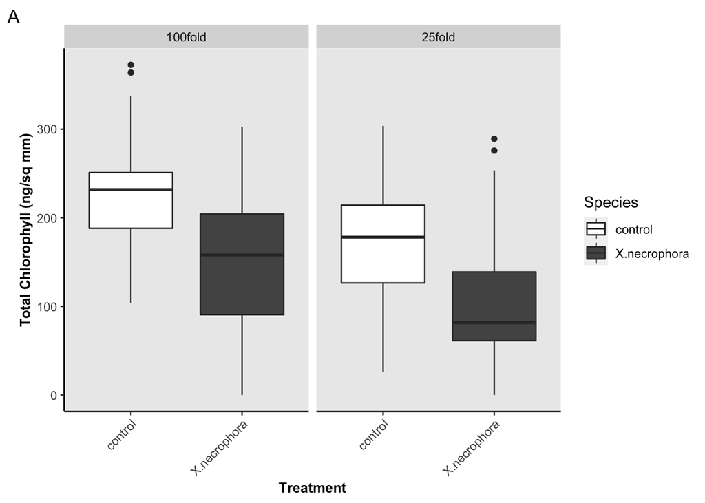

```r
##Extract all control (ES5: 7 DOE)
ES5.control <- subset(ES5.mod, Treatment== "control")
ES5.Xn <- subset(ES5.mod, Treatment== c("DMCC2126", "DMCC2127", "DMCC2165"))

ES5.control <- ES5.control %>%
  add_column(Species = "control")

ES5.Xn <- ES5.Xn %>%
  add_column(Species = "X.necrophora")

ES5.mod.v2 <- rbind(ES5.control, ES5.Xn)


ES5.mod.ggplot <- ggplot(ES5.mod.v2, aes(x = reorder(Species, -chl, na.rm = TRUE), y = chl, fill = Species)) + geom_boxplot() + #geom_point(aes(colour = factor(LeafSampleNumber)))# + geom_jitter()
  #scale_fill_grey(start = 1, end = 0.4) + labs(tag = "A") +
  scale_fill_manual(values = c("#FFFFFF", "#545454"))+ labs(tag = "A") +
  xlab("Treatment") + ylab("Total Chlorophyll (ng/sq mm)") +
  theme(plot.title = element_text(size = 12, hjust = 0.1, face = "bold"), axis.title.x = element_text(size=10, face = "bold"), axis.title.y = element_text(size = 10, face = "bold"), axis.text.x = element_text(angle = 45, hjust = 1)) +
  theme(panel.border = element_blank(), panel.grid.major = element_blank(), panel.grid.minor = element_blank(), axis.line = element_line(colour = "black")) +
  facet_wrap(~ Dilution)
ES5.mod.ggplot #+ stat_compare_means(aes(group = Dilution), label = "p.signif", na.rm = TRUE)
```

## Individual plot for panel B

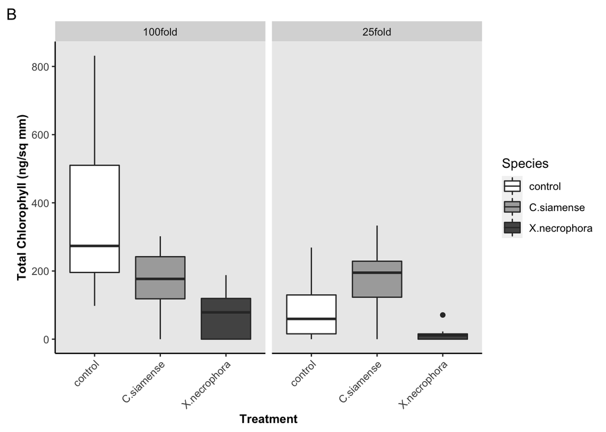

```r
##Extract all control (ES2), colletrichum, and X. necrophora
ES2.control <- subset(ES2.mod, Treatment== "control")
ES2.coll <- subset(ES2.mod, Treatment== "DMCC2966")
ES2.Xn <- subset(ES2.mod, Treatment== c("DMCC2126", "DMCC2127", "DMCC2165"))

ES2.control <- ES2.control %>%
  add_column(Species = "control")

ES2.coll <- ES2.coll %>%
  add_column(Species = "C.siamense")

ES2.Xn <- ES2.Xn %>%
  add_column(Species = "X.necrophora")

ES2.mod.v2 <- rbind(ES2.control, ES2.coll, ES2.Xn)

#plot for figure by species by dilution factor

#Reorganizing for plotting

ES2.mod.v2$Species <- factor(ES2.mod.v2$Species,                 # Relevel group factor
                         levels = c("control", "C.siamense", "X.necrophora"))

ES2.mod.v2.ggplot <- ggplot(ES2.mod.v2, aes(x = reorder(Species, -chl, na.rm = TRUE), y = chl, fill = Species)) + geom_boxplot() + #geom_point(aes(colour = factor(LeafSampleNumber)))# + geom_jitter()
 # scale_fill_grey("control" = 1, "C.siamense" =0.7, "X.necrophora"= 0.4)
  scale_fill_manual(values = c("#FFFFFF", "#AAAAAA", "#545454"))+ labs(tag = "B") +
  xlab("Treatment") + ylab("Total Chlorophyll (ng/sq mm)") +
  theme(plot.title = element_text(size = 12, hjust = 0.1, face = "bold"), axis.title.x = element_text(size=10, face = "bold"), axis.title.y = element_text(size = 10, face = "bold"), axis.text.x = element_text(angle = 45, hjust = 1)) +
  theme(panel.border = element_blank(), panel.grid.major = element_blank(), panel.grid.minor = element_blank(), axis.line = element_line(colour = "black")) +
  facet_wrap(~ Dilution)
ES2.mod.v2.ggplot #+ stat_compare_means(aes(group = Dilution), label = "p.signif", na.rm = TRUE)
```

## Plot composite figure 1

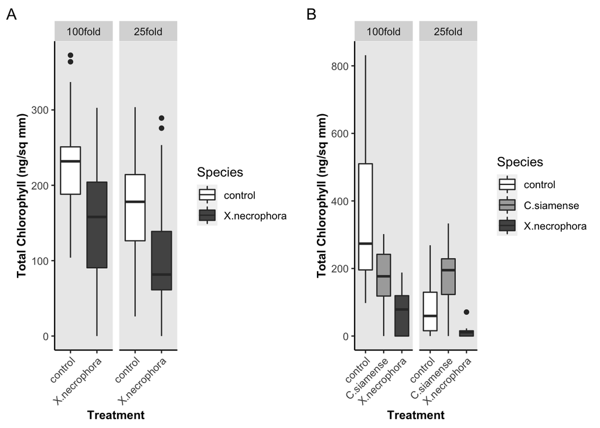

```r
###Grid for composite figure 1 (updated 10/25/2021). Using ES2 and ES5 only.
gridExtra::grid.arrange(ES5.mod.ggplot, ES2.mod.v2.ggplot, ncol=2) #+ ggtitle("Digital chlorophyll content by treatment")
```

## Plotting individual plots and composite figure 3

### Individual panels A, B, C, and D.

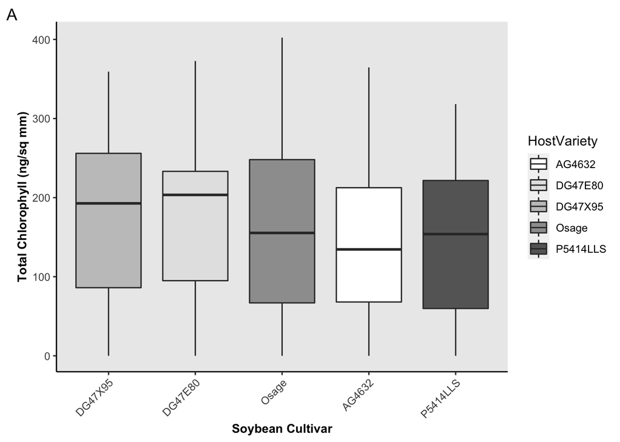

```r
###Plot HostVariety only w/ outliers
ES13B.ByHosCult <- ggplot(ES13B.mod, aes(x = reorder(HostVariety, -chl, na.rm = TRUE), y = chl, fill=HostVariety)) + geom_boxplot() + #+ geom_point(aes(colour = factor(LeafSampleNumber)))# + geom_jitter()
  scale_fill_grey(start = 1, end = 0.4) + labs(tag = "A") +
  xlab("Soybean Cultivar") + ylab("Total Chlorophyll (ng/sq mm)") +
  theme(plot.title = element_text(size = 12, hjust = 0.1, face = "bold"), axis.title.x = element_text(size=10, face = "bold"), axis.title.y = element_text(size = 10, face = "bold"), axis.text.x = element_text(angle = 45, hjust = 1)) +
  theme(panel.border = element_blank(), panel.grid.major = element_blank(), panel.grid.minor = element_blank(), axis.line = element_line(colour = "black"))
ES13B.ByHosCult
```

```r
#stat_summary(fun.data = give.n, geom = "text", position = position_dodge(width = 0.75), size = 3) # + facet_wrap(~ HostVariety)
```

# Individual panel B

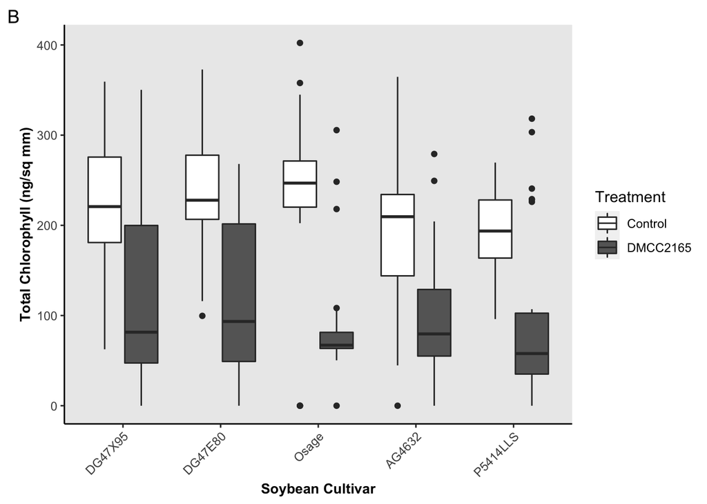

```r
###Plot by variety by treatment w/ outliers
ES13B.ggplot.ByCultByTreat <- ggplot(ES13B.mod, aes(x = reorder(HostVariety, -chl, na.rm = TRUE), y = chl, fill=Treatment)) + geom_boxplot() + #+ geom_point(aes(colour = factor(LeafSampleNumber)))# + geom_jitter()
    scale_fill_grey(start = 1, end = 0.4) + labs(tag = "B") +
    xlab("Soybean Cultivar") + ylab("Total Chlorophyll (ng/sq mm)") +
    theme(plot.title = element_text(size = 12, hjust = 0.1, face = "bold"), axis.title.x = element_text(size=10, face = "bold"), axis.title.y = element_text(size = 10, face = "bold"), axis.text.x = element_text(angle = 45, hjust = 1)) +
    theme(panel.border = element_blank(), panel.grid.major = element_blank(), panel.grid.minor = element_blank(), axis.line = element_line(colour = "black"))
ES13B.ggplot.ByCultByTreat
```

```r
#stat_summary(fun.data = give.n, geom = "text", position = position_dodge(width = 0.75), size = 3) # + facet_wrap(~ HostVariety)
```

## Panel C

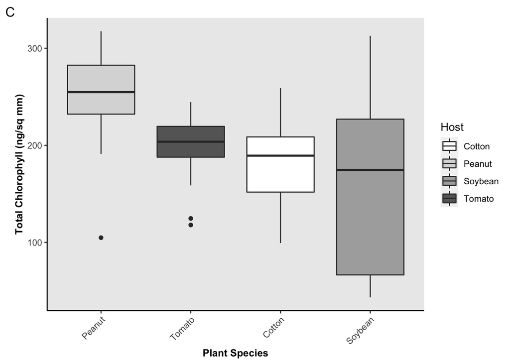

```r
###Plot By Host only w/ outliers for grid
ES14A.ggplot.ByHost <- ggplot(ES14A.mod, aes(x = reorder(Host, -chl, na.rm = TRUE), y = chl, fill=Host)) + geom_boxplot() + #+ geom_point(aes(colour = factor(LeafSampleNumber)))# + geom_jitter()
    scale_fill_grey(start = 1, end = 0.4) + labs(tag = "C") +
    xlab("Plant Species") + ylab("Total Chlorophyll (ng/sq mm)") +
    theme(plot.title = element_text(size = 12, hjust = 0.1, face = "bold"), axis.title.x = element_text(size=10, face = "bold"), axis.title.y = element_text(size = 10, face = "bold"), axis.text.x = element_text(angle = 45, hjust = 1)) +
    theme(panel.border = element_blank(), panel.grid.major = element_blank(), panel.grid.minor = element_blank(), axis.line = element_line(colour = "black"))
  #stat_summary(fun.data = give.n, geom = "text", position = position_dodge(width = 0.75), size = 3) # + facet_wrap(~ HostVariety)
ES14A.ggplot.ByHost
```

## Panel D

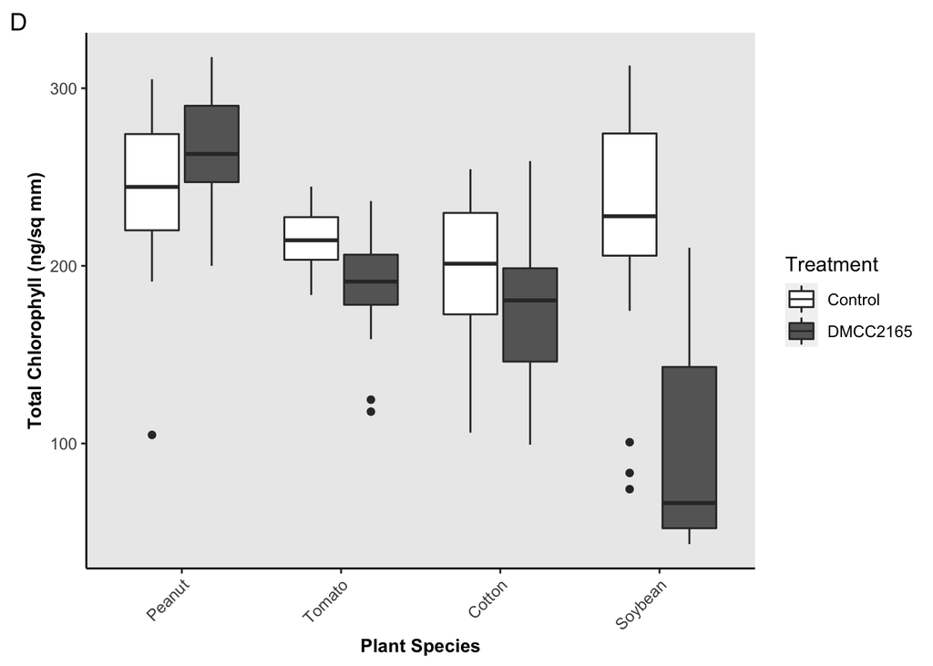

```r
###Plot by host by treatment w/ outliers
ES14A.ggplot.ByHostByTreat <- ggplot(ES14A.mod, aes(x = reorder(Host, -chl, na.rm = TRUE), y = chl, fill=Treatment)) + geom_boxplot() + #+ geom_point(aes(colour = factor(LeafSampleNumber)))# + geom_jitter()
    scale_fill_grey(start = 1, end = 0.4) + labs(tag = "D") +
    xlab("Plant Species") + ylab("Total Chlorophyll (ng/sq mm)") +
    theme(plot.title = element_text(size = 12, hjust = 0.1, face = "bold"), axis.title.x = element_text(size=10, face = "bold"), axis.title.y = element_text(size = 10, face = "bold"), axis.text.x = element_text(angle = 45, hjust = 1)) +
    theme(panel.border = element_blank(), panel.grid.major = element_blank(), panel.grid.minor = element_blank(), axis.line = element_line(colour = "black"))
  #stat_summary(fun.data = give.n, geom = "text", position = position_dodge(width = 0.75), size = 3) # + facet_wrap(~ HostVariety)
ES14A.ggplot.ByHostByTreat
```

## Composite figure 3

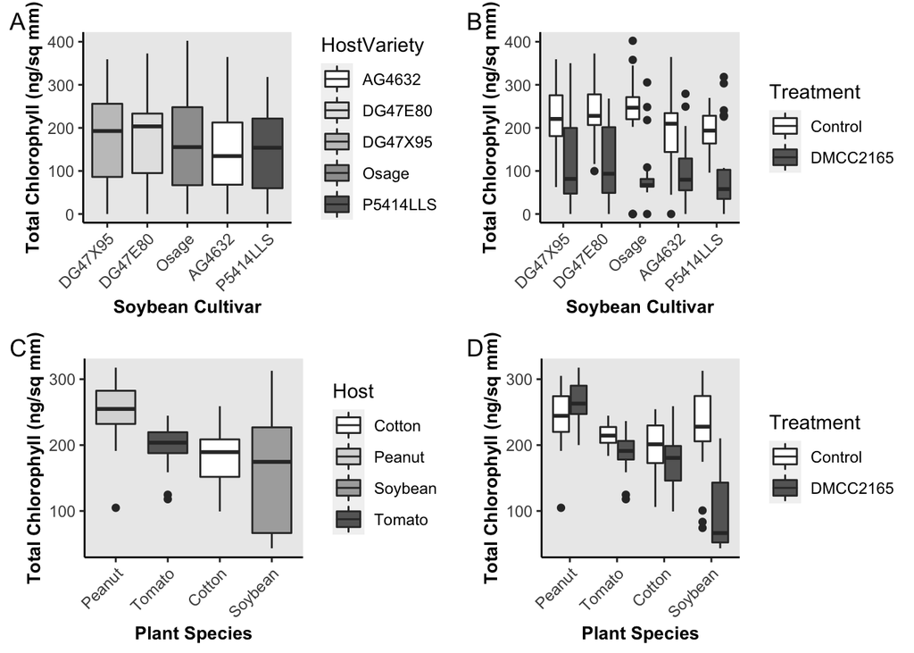

```r
###Grid for composite figure 3 (08/16/2021). Using ES13B and ES14 only.
gridExtra::grid.arrange(ES13B.ByHosCult,ES13B.ggplot.ByCultByTreat , ES14A.ggplot.ByHost, ES14A.ggplot.ByHostByTreat, ncol=2) #+ ggtitle("Digital chlorophyll content by treatment")
```